# Optimization of Pre-NSPIRE Inspection Work via Monte Carlo Simulation

Author

Joël R. Pradines, Ph.D.

Published

September 2, 2026

### Reader’s Guide

This report bridges property maintenance with Operations Research [[link]](https://www.informs.org/Explore/Operations-Research-Analytics) in the context of preparation work prior to a building inspection. Because it contains both operational directives and mathematical work, it is designed to be read modularly based on your interest:

**For a rapid strategic overview**: Read Section 1. This provides an executive summary and key operational findings.  
**For a detailed analysis of the simulation results**: Read Section 2 to examine parameter sensitivities, operational thresholds, and quantitative risk assessments.  
**For the underlying methodology**: Jump to Section 3 for the mathematical framework, stochastic modeling mechanics, and DAG workflow mapping.  
**For reproducibility and software architecture**: Refer to the Appendices to review the simulation configuration files and the complete R codebase.

# 1 Executive Summary & Key Findings

Preparing a property for a HUD NSPIRE inspection is a complex operational challenge governed by rigid constraints: labor limits, task dependencies, and tenant behavior.

This document presents a data-driven approach to optimizing this pre-inspection workflow. By using Monte Carlo simulation, we execute thousands of “virtual inspections,” each modeling the random emergence of defects, the subsequent maintenance response, and HUD’s random unit sampling. This probabilistic engine stress-tests a property’s risk profile by generating a distribution of potential scores. To enforce the physical laws of maintenance, the workflow is mapped as a Directed Acyclic Graph (DAG), guaranteeing proper task sequencing and compliance with mandatory temporal lockouts (Section 3.4).

Relying on modular configuration files—which define specific maintenance tasks, floor plans, labor scenarios, and scoring schemes—the model is adaptable and can generate estimates for any property. However, its true value is prescriptive: it isolates the mathematical architecture of an inspection to identify critical operational levers and their exact failure thresholds.

Ultimately, this document serves as a proof-of-concept for the utility of [Operations Research](https://www.informs.org/Explore/Operations-Research-Analytics) in property management. By mapping the complex interactions between time, labor, and probability, it translates raw data into concrete operational directives—identifying staffing requirements, exposing the physical limits of overtime, and defining the precise timelines needed to guarantee regulatory compliance.

Section 2 explores the results obtained with simulations, detailing the specific thresholds where standard preparation strategies fail. For readers interested in the structural logic of the model, the mathematical architecture and simulation mechanics—including the Directed Acyclic Graph (DAG) workflow mapping—are detailed in Section 3, prior to the appendices, which provide modeling parameters and simulator code.

# 2 Detailed Results

## 2.1 Operational Reality: The Transit Friction Tax

Models that treat maintenance technicians as frictionless agents produce inaccurate time estimates. Standard approaches typically calculate only pure “wrench time”—the minutes required to execute a repair. This ignores the physical and human constraints of routing labor through a segmented residential environment.

To model operational execution, the simulation incorporates “transit friction” into the schedule:

To quantify the operational impact of these constraints, the simulation executed 10,000 paired scenarios—comparing pure wrench time against friction-adjusted time—for a standard 50-unit property. Results are summarized in Figure 1.

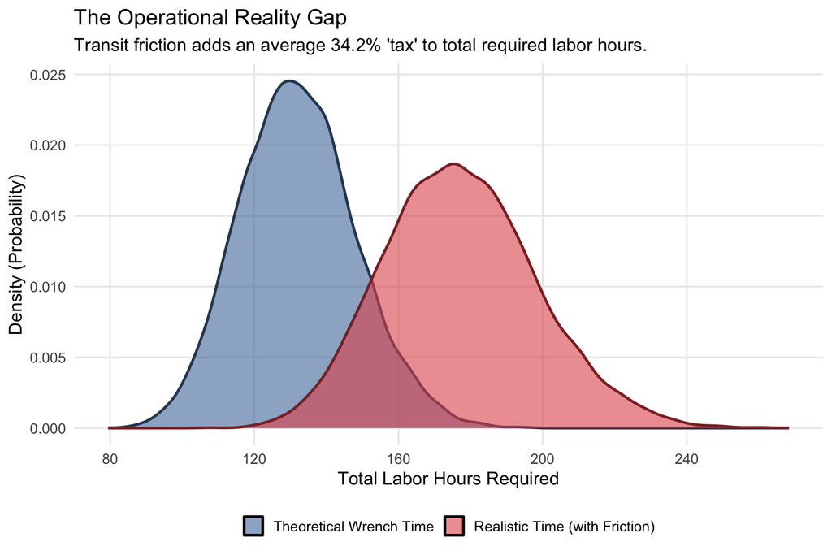

### Conclusions

**The 34% Labor Tax**: Transit friction is not a measure of workforce inefficiency, but a structural constraint. The compounding effect of minor 5- and 15-minute delays generates a 34.2% expansion in total required labor hours.

**Budgetary Blind Spot**: Calculating staffing requirements, prep timelines, or overtime budgets based solely on idealized task lists underestimates required resources by one-third. Optimizing execution requires scheduling workflows that prioritize spatial clustering—keeping technicians in a single unit as long as possible to minimize this transit overhead.

## 2.2 Audit Catch Rate ($\alpha_\text{audit}$)

To identify critical thresholds and optimal resource allocations, we first evaluate the pre-inspection audit rate ($\alpha_\text{audit}$). This parameter defines the probability that a defect is identified and resolved prior to the HUD inspection.

To quantify the impact of audit efficacy on compliance risk, $\alpha_\text{audit}$ was varied from 0.05 to 0.95, executing $K=1,000$ Monte Carlo iterations per step. Figure 2 provides a visual summary of the resulting score distributions, bounded by a red failure threshold at 60.

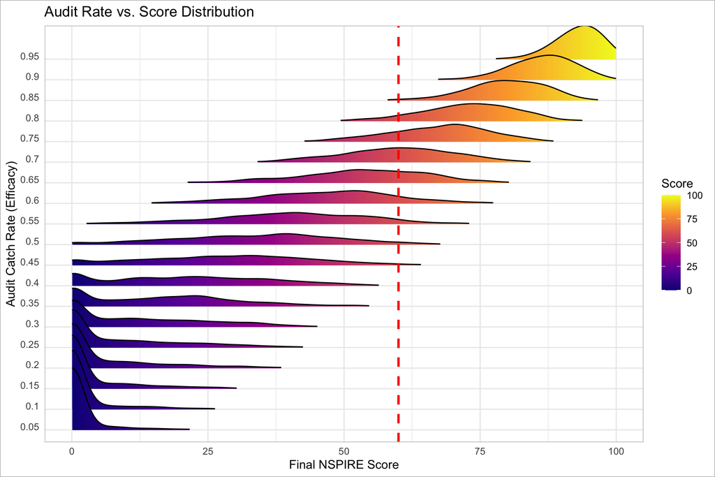

Figure 2: Risk Transition: Audit Rate vs. Score Distribution.

Failure risk is almost completely eliminated when $\alpha_\text{audit} \geq 0.90$. Figure 3 further illustrates the transition from high to low risk as $\alpha_\text{audit}$ increases from 0.55 to 0.85. Failure risk is estimated by the proportion of the 1,000 simulations yielding a score below 60, represented visually by the area under the density curve to the left of the red line.

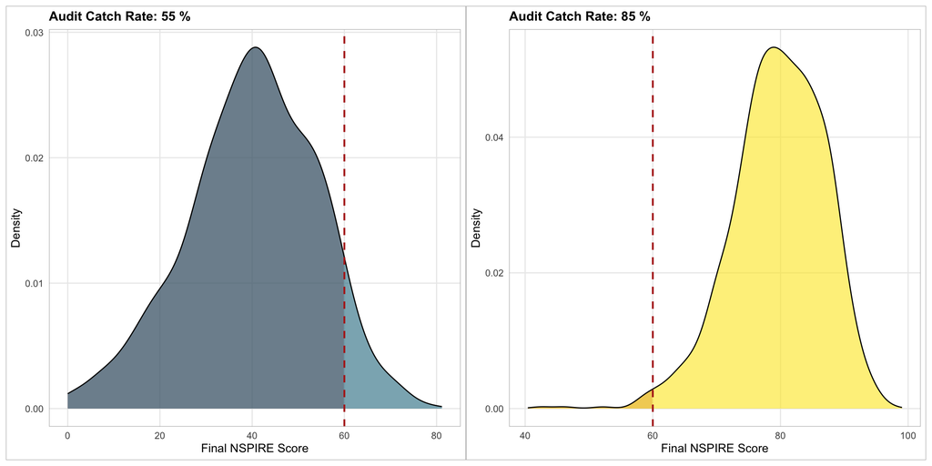

Figure 3: Examples of Score Distribution: $\alpha_\text{audit} = 0.55$ (left) and $\alpha_\text{audit} = 0.85$ (right).

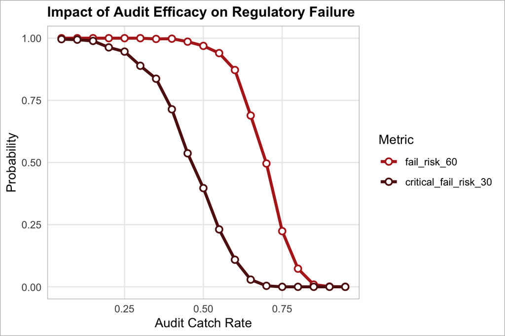

Figure 4: Failure probabilities at scores 30 and 60 as a function of audit catch rate $\alpha_\text{audit}$.

While failure probabilities measure the likelihood of non-compliance, they do not capture the severity of worst-case outcomes. To quantify this downside risk, we use the tail-drop metric $\tau$ (Equation 1). This metric provides a simple summary of the gap between the expected median score and a “bad day” (the 5th percentile worst-case scenario) relative to the median. It is therefore quantifying the relative uncertainty, or volatility, of the inspection score. To understand how $\tau$ responds to audit efficacy, we first examine how the underlying score statistics evolve in Figure 5.

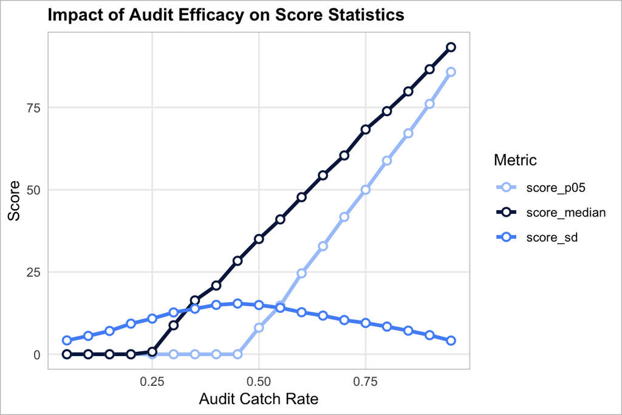

Figure 5: Score statistics as a function of audit catch rate $\alpha_\text{audit}$.

As $\alpha_\text{audit}$ exceeds 0.25, the median score rises linearly. Once $\alpha_\text{audit}$ climbs above 0.45, the 5th percentile score ($P_{05}$) also rises, but at a steeper rate. This accelerated improvement at the bottom end narrows the gap between the median and the worst-case outcomes. This variance compression—also reflected by the decreasing standard deviation—drives the profile of the tail-drop metric $\tau$, displayed in Figure 6.

In short, a small $\tau$ indicates high operational predictability: it guarantees that even on a worst-case inspection day, the final score will not fall far below expectations.

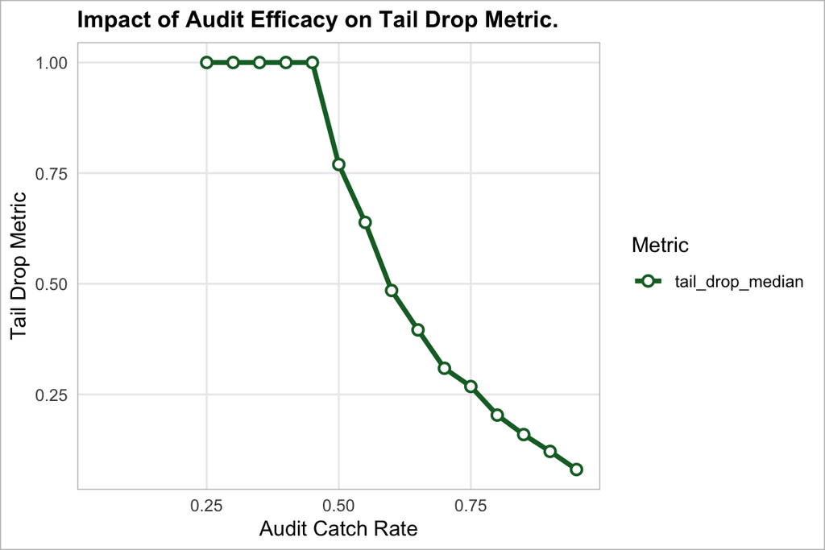

Figure 6: Tail drop metric $\tau$ as a function of audit catch rate $\alpha_\text{audit}$.

### Conclusions

- **Futility Threshold ($\alpha_\text{audit} \leq 0.25$)**: Below 25% efficacy, quality assurance efforts provide no measurable benefit. Because of the absolute scoring floor (0), low-efficacy audits fail to improve the final inspection outcome.
- **Volatility Reduction ($0.45 < \alpha_\text{audit} < 0.90$)**: As the catch rate exceeds 0.45, the worst-case outcomes ($P_{05}$) improve faster than the median score. This compresses the overall score variance and rapidly drives down the Tail Drop metric ($\tau$), meaning that the final outcome is more predictable.
- **Compliance Baseline ($\alpha_\text{audit} \geq 0.90$)**: To reliably eliminate the risk of regulatory failure (a score below 60), the internal audit process must intercept at least 90% of pre-existing defects.

## 2.3 Time Constraints: Notice of Inspection ($t_\text{start}$)

A successful NSPIRE inspection assumes the maintenance team has adequate time to complete necessary repairs. However, HUD inspection notices can vary significantly, often providing only 14 to 30 days of warning.

As $t_\text{start}$ decreases, the volume of identified defects remains constant, but the time available to both execute repairs and transit between locations compresses.

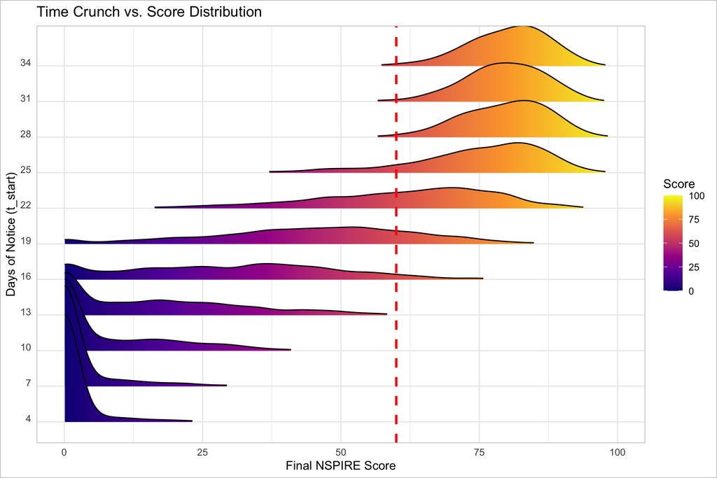

As visualized in Figure 7, the score distribution remains stable when $t_\text{start} \geq 28$. However, as the notice period decreases, the distribution broadens and shifts negatively, ultimately falling entirely below the passing threshold.

The initial impact of this schedule compression is financial, as shown in Figure 8.

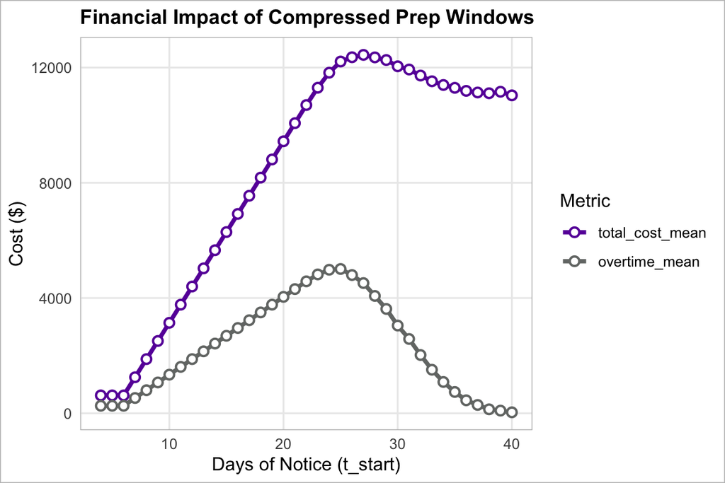

The left side of Figure 8 presents a seemingly counter-intuitive trend: as the notice period drops below 20 days, total expected costs decrease sharply. This reduction does not reflect efficiency gains; rather, it quantifies deferred maintenance—a backlog of tasks that cannot be completed prior to the inspection.

Figure 9 illustrates the regulatory consequences of this capacity exhaustion.

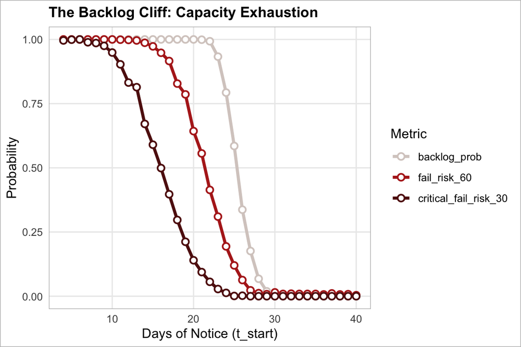

Figure 9: Probability of generating a task backlog and the resulting regulatory failure risk (< 60) under compressed timelines.

Finally, we map the Tail Drop metric ($\tau$) as a function of the preparation window (Figure 10). This demonstrates how temporal limits affect the volatility of outcomes.

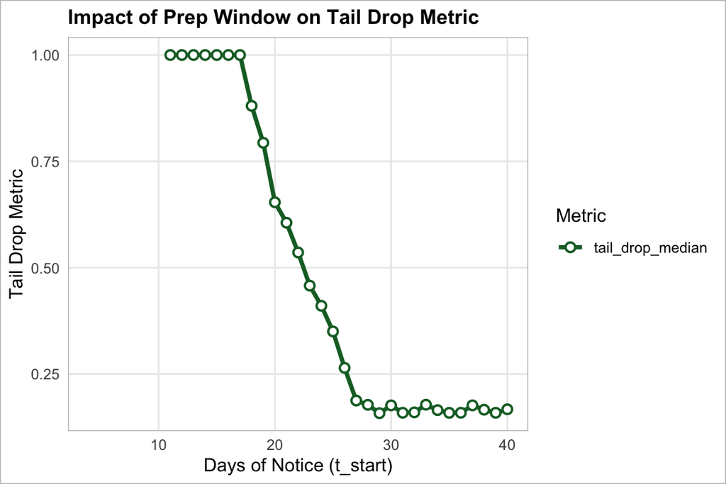

Figure 10: Tail Drop Metric $\tau$ as a function of the preparation window. High $\tau$ indicates massive outcome volatility.

Finally, we map the Tail Drop metric ($\tau$) as a function of the notice period (Figure 10) to demonstrate how temporal limits affect outcome volatility. As the schedule compresses below 20 days, $\tau$ sharply increases to its maximum value, meaning that any predictability in the inspection score completely disappears.

## 2.4 Staffing Requirements: The Capacity Curve

Having established that a compressed schedule leads to capacity exhaustion, the model can be inverted to estimate necessary staffing levels. While targeting a specific inspection score might seem intuitive, a passing score is not guaranteed by labor alone; if the audit catch rate is too low, the property may fail regardless of crew size. Therefore, the chosen target is the backlog value, which, given a notice period, is determined by crew size. For a given audit catch rate, we ask a specific question: what is the minimum headcount required to achieve a 99.9% probability of clearing all identified repairs?

Using a binary search algorithm wrapped around the Monte Carlo engine ($K=1,000$ iterations per step), we mapped the required workforce capacity to reach the target backlog—$P(\text{Backlog} > 0) \le 0.001$—as a function of the notice period.

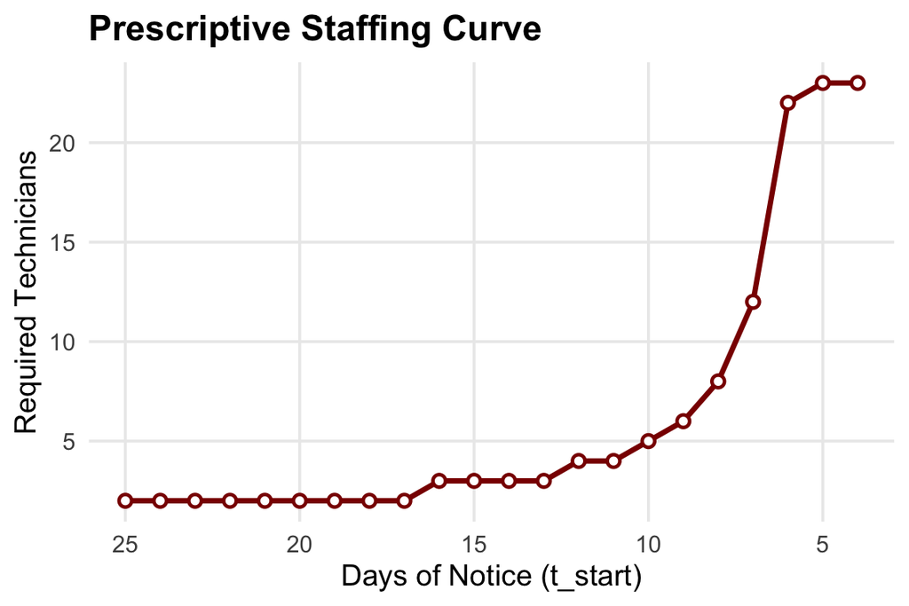

Figure 11: Prescriptive Staffing Curve: Required technicians as a function of days of notice ($t_\text{start}$).

As demonstrated in Figure 11, the resulting capacity curve is non-linear. With a notice period of 20 to 25 days, a baseline crew of two technicians can complete the repairs. However, dropping below the 15-day threshold triggers an exponential surge in labor demand. To prepare this property in under a week, authorizing overtime is insufficient; management must deploy a team of over 20 technicians.

## 2.5 Post-Prep Decay: The “Too Early” Penalty ($t_\text{end}$)

In Section 2.3, we established that a compressed schedule causes capacity exhaustion. A common operational response to this constraint is to complete all pre-inspection repairs as early as possible.

However, residential properties are dynamic environments subject to continuous wear. The time gap between the completion of repairs ($t_\text{end}$) and the actual day of the HUD inspection exposes the property to a natural re-accumulation of defects.

To quantify this temporal decay risk, $t_\text{end}$ was varied from 0 to 35 days prior to the inspection. To isolate the effect of decay from capacity constraints, the notice period ($t_\text{start}$) was fixed at 45 days, ensuring the maintenance team had sufficient capacity and zero backlog risk.

Figure 12 illustrates the erosion of the property’s safety margin as this time gap widens.

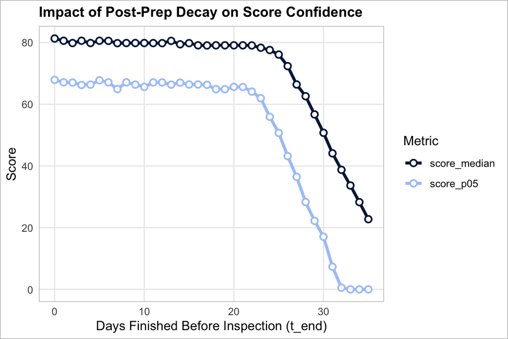

Figure 12: Erosion of the Median and 5th Percentile ($P_{05}$) scores as the gap between prep completion and the inspection date widens.

Figure 13 illustrates how this score reduction translates into regulatory failure risk.

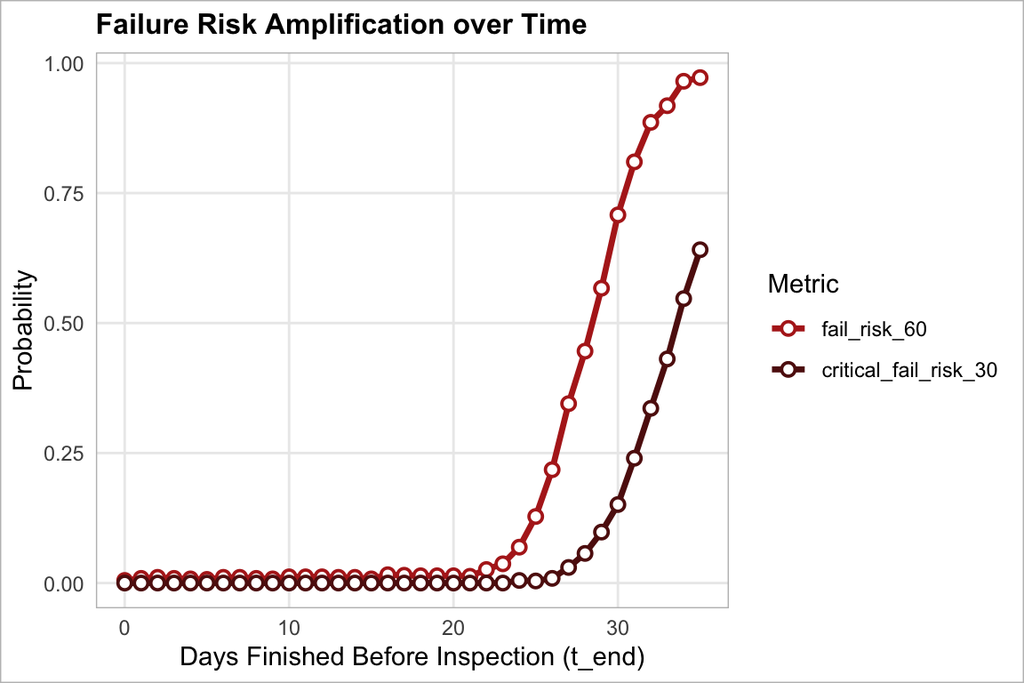

Figure 13: The compounding probability of regulatory failure caused by natural property decay during the post-prep waiting period.

### Conclusions

**Decay Threshold**: Completing preparations too early introduces significant compliance risk that manifests as a threshold rather than a linear progression. The data demonstrates that a property remains stable if idle for up to three weeks. However, under the baseline parameters, a property with a near-zero failure risk at $t_\text{end} = 0$ exhibits an exponential increase in failure probability if left idle beyond 25 days, reaching near-certain failure by day 35.

**Optimal Execution Window**: Combined with the capacity insights from Section 2.4, these results define a strict operational window. A maintenance team must start late enough to avoid an excessive decay penalty ($t_\text{end} \le 25$ days) but early enough to avoid capacity exhaustion ($t_\text{start}$ constraint). Maximizing NSPIRE performance requires precise, “just-in-time” repair scheduling.

## 2.6 Spatial Heterogeneity and the “Lottery Effect”

NSPIRE scores are highly sensitive to the spatial distribution of defects. HUD’s sampling protocol selects a subset of units to represent the entire property. While reliable for uniformly maintained buildings, this sampling introduces significant variance—the “Lottery Effect”—in properties with tenant heterogeneity.

To quantify this, the proportion of standard, low-impact tenants was varied from 100% (perfectly homogeneous) down to 70%. To isolate the risk of sampling variance and ensure the building’s overall quality was not artificially degraded, the simulation enforced a strict “Conservation of Defects”. As destructive tenants were introduced into the model to generate defect clusters, the baseline multiplier for the remaining standard units was dynamically reduced to offset them. This balancing guarantees that the global expected severity remains constant, allowing the model to isolate the impact of spatial clustering.

To measure how this spatial clustering impacts regulatory risk, we again apply the Tail Drop metric ($\tau$), which isolates the expansion of the worst-case outcomes relative to the median score. Figure 14 illustrates how this downside risk behaves as a function of the tenant mix.

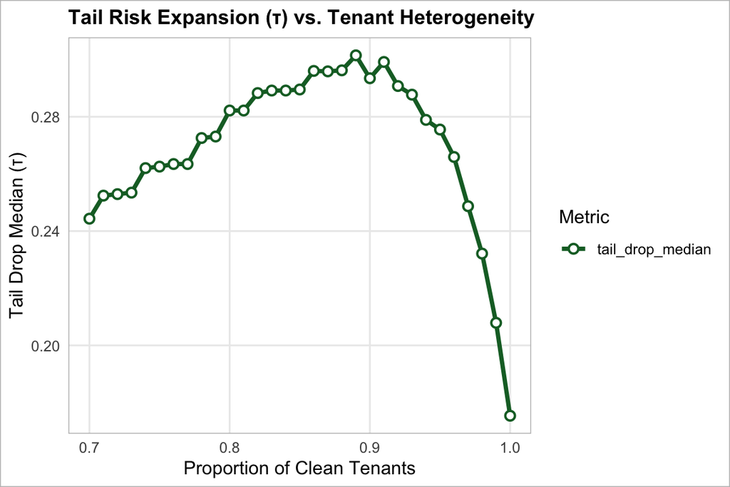

Figure 14: Tail Risk Expansion. As the building deviates from perfect homogeneity, the left tail of the score distribution detaches from the median, maximizing the statistical risk of a catastrophic inspection.

Reading Figure 14 from right to left, as homogeneity breaks down, the Tail Drop metric $\tau$ (Equation 1)—which quantifies the unpredictability of the inspection score—sharply increases, peaking near $p = 0.89$. This visualizes the core of the Lottery Effect: while the median score of the building remains relatively stable, the 5th percentile worst-case score drops significantly, increasing the volatility measure $\tau$. To understand the physical mechanisms driving this expansion, and its subsequent contraction at extreme heterogeneity, we must examine the physical defects themselves.

Figure 15 visualizes the physical state of the building prior to HUD scoring.

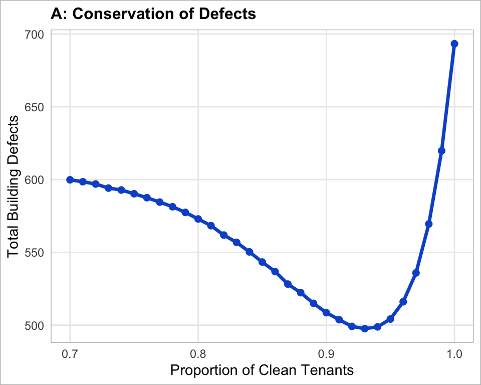

(a) Conservation of Defects

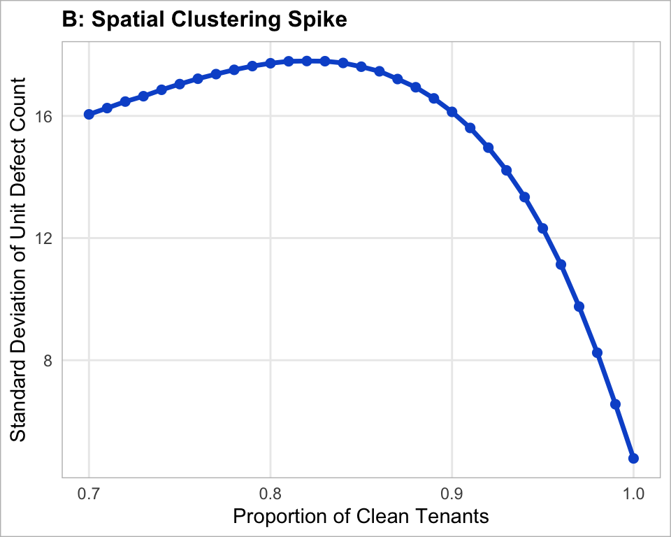

(b) Spatial Clustering Spike

Figure 15: The Physical Reality of Heterogeneity. As the building becomes more homogeneous (moving left to right), the spatial clustering of defects collapses (Plot B). The U-shape in total defects (Plot A) reveals the physical capacity limits of individual units.

The data reveals an effect driven by physical constraints (Plot A). As the proportion of clean tenants increases (reading left to right), the balancing equation forces a shrinking number of destructive units to absorb the remaining defects. However, these few units quickly hit a physical ceiling, as a single apartment contains a limited number of inspectable items. Consequently, excess theoretical defects are truncated, causing the building’s total defect count to artificially drop to a minimum near $p = 0.93$.

Once $p$ exceeds $0.94$, the defect burden shifts back to the clean units. Because these standard units are numerous, they can easily absorb the expected defects without hitting physical truncation limits, allowing the total defect volume to rapidly rebound to its theoretical expectation.

Figure 16 demonstrates how this physical clustering translates into regulatory failure.

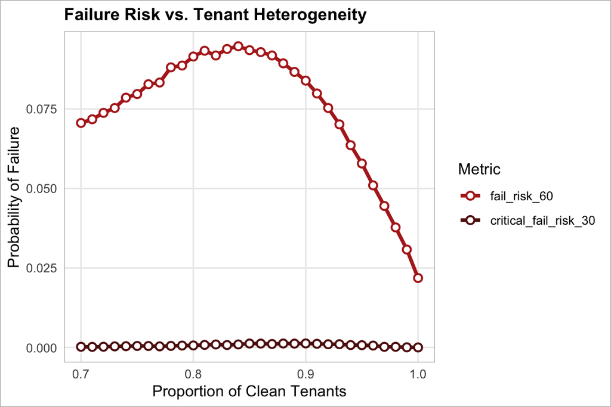

Figure 16: The ‘Lottery Effect’ on Regulatory Risk. Despite having fewer overall defects, buildings with highly concentrated tenant damage experience a massive spike in inspection failure probability.

Despite the highly heterogeneous building containing fewer total physical defects than the perfectly homogeneous baseline, its probability of regulatory failure nearly quadruples (spiking from ~2.5% to ~9.5%).

### Conclusions

**Lottery Effect** Under the NSPIRE scoring protocol, the impact of a destructive tenant cannot be averaged out. Because HUD’s scoring relies on a random sample, selecting just one or two heavily degraded units can immediately drop an otherwise pristine property below a passing threshold.

**Targeted Pre-Inspections** A property with fewer total defects but high spatial clustering carries a higher statistical risk of failure than a uniformly degraded property. If management can identify high-impact tenants, those specific units should be prioritized for targeted audits and repairs, as they pose a disproportionate threat. A potential proactive strategy to identify these high-risk units is to monitor for historically low rates of tenant service requests, which often mask severe deferred maintenance—a hypothesis that merits testing with historical service request data.

# 3 Methodology & Mathematical Framework

## 3.1 The NSPIRE Scoring Mechanism

The inspection divides a property into distinct locations and evaluates defects based on severity.

### Definitions and Sets

- **Severity:** $s \in \{\text{LT}, \text{S}, \text{STD}\}$ (Life-Threatening, Severe, Standard)
- **Location:** $l \in \{\text{Unit}, \text{Inside}, \text{Outside}\}$
- $N$: Total number of units in the property.
- $n(N)$: The HUD-mandated sample size function, where $n$ is a discrete function of $N$.
- $C_{s,l}$: Total count of defects existing in the property.
- $c_{s,l}$: Observed count of defects recorded during the inspection.
- $w_{s,l}$: Static point weight (penalty) assigned to a defect.

### Deduction Function

The total point deduction $D$ is a summation over all severities and locations. For Unit locations, the observed defects are normalized by the sample size $n(N)$, which effectively scales the deduction based on the inspection tier:

$$D = \sum_{s} \sum_{l \in \{\text{Inside}, \text{Outside}\}} (c_{s,l} \cdot w_{s,l}) + \sum_{s} \left( \frac{c_{s,\text{Unit}}}{n(N)} \cdot w_{s,\text{Unit}} \right)$$

### Raw Continuous Score

The base score originates at 100 and is bounded at zero using the Heaviside step function $H(x)$:

$$S_{raw} = (100 - D) \cdot H(100 - D)$$
which acts as a zero-bound constraint defined by:
$$H(x) = \begin{cases} 1 & \text{if } x \ge 0 \\ 0 & \text{otherwise} \end{cases}$$

### Operational Compliance Function (Failsafe)

A score $\ge 60$ mathematically passes, but the presence of any Life-Threatening (LT) defect forces an immediate 24-hour mitigation compliance failure. Let $n_{LT}$ represent the total observed LT defects:
$$n_{LT} = \sum_{l} c_{\text{LT},l}$$

We model this regulatory mandate as a strict compliance bound using the Heaviside function $H(x)$ defined above. Namely, if even one LT defect is observed ($n_{LT} \ge 1$), the term $(0.5 - n_{LT})$ becomes negative. This drives the function to output a zero, resulting in an automatic failure regardless of the raw score:
$$S_{eff} = S_{raw} \cdot H(0.5 - n_{LT})$$

## 3.2 Probabilistic Sampling and Realizations

The inspection score is not a single deterministic value). Instead, it is a **random variable**, modeling the final outcome of multiple stochastic events. For example, whether a specific kitchen GFCI fails prior to the inspection is a stochastic physical event; whether the HUD inspector randomly selects that specific unit for evaluation is a stochastic sampling event.

Due to this variance, executing a single simulation realization provides insufficient information. However, by running thousands of virtual inspections via Monte Carlo simulations, we generate a comprehensive score distribution. This allows the model to move beyond deterministic point estimates and mathematically quantify probabilities, such as the risk of regulatory non-compliance (scoring below 60).

### Stochastic Unit Sampling

HUD inspection protocols dictate that units are randomly sampled. For a property with $N$ total units, the inspector chooses a subset $n(N)$ based on the tiered sampling schedule defined in Table 1.

Table 1: HUD NSPIRE Tiered Sampling Schedule

| Total Units (N) | Inspected Units (n) | SearchTerms |
| --- | --- | --- |
| 1–5 | All units | 1 2 3 4 5 |
| 6–7 | 6 | 6 7 |
| 8 | 7 | 8 |
| 9–10 | 8 | 9 10 |
| 11–12 | 9 | 11 12 |
| 13–14 | 10 | 13 14 |
| 15–16 | 11 | 15 16 |
| 17–18 | 12 | 17 18 |
| 19–21 | 13 | 19 20 21 |
| 22–24 | 14 | 22 23 24 |

[output cut: 12 more lines]

In high-rise properties ($N > 100$), the inspection score tends to be highly stable because extreme outcomes naturally converge toward the expected value (Law of Large Numbers). However, for small to mid-sized properties ($N \leq 50$), this random sampling creates significant relative variations. Because the inspector evaluates a limited subset of units, the observed defect count ($c_{s,\text{Unit}}$) can deviate substantially from the actual overall condition of the building ($C_{s,\text{Unit}}$). This sampling variance drives a wider spread of possible final scores in mid-sized properties.

### Realization of Deductions

Let $I_{u}$ be an indicator variable for unit $u$, that is, $I_u = 1$ if unit $u$ is selected for inspection, and $0$ otherwise. The observed defect count $c_{s,\text{Unit}}$ for a specific simulation realization $\omega$ is defined by the subset of selected units:
$$c_{s,\text{Unit}}(\omega) = \sum_{u=1}^{N} I_u(\omega) \cdot \mathbb{1}(\text{unit } u \text{ has defect } s)$$
where $\mathbb{1}(\text{statement})$ is 1 if $\text{statement}$ is true and 0 otherwise.The model calculates the realization $D(\omega)$ for each simulation $k$ in the Monte Carlo ensemble. The set of all realizations records the variance, inherent in the sampling process, which is the primary driver of sampling volativity in mid-sized properties.

### Task Execution Times and Mixture Distributions

Just as the inspector’s choice of units is random, the time required to complete a maintenance task is never a fixed number.To model this physical reality, we treat execution time $t_i$ as a random variable drawn from a bounded Beta-PERT (Program Evaluation and Review Technique) distribution. PERT is widely used in project management because it relies on three intuitive estimates: an optimistic minimum ($a$), a most likely mode ($m$), and a pessimistic maximum ($b$).

However, tasks often exist in distinctly different physical states. Consider a sink drain: it might simply require a quick manual adjustment by a technician (State 1), or it might require a licensed plumber to replace the downstream PVC P-trap (State 2). To account for this, the execution time $t_i$ is drawn from a mixture distribution, weighted by the physical probability of each state ($p_{i,k}$):
$$f(t_i) = \sum_{k} p_{i,k} \cdot \text{PERT}(t; a_k, m_k, b_k)$$
Using a single “average time” for such a task would be inappropriate, as it would plan for an event that never actually happens. As illustrated in Figure 17, the mixture distribution correctly captures the bifurcated reality of the repair.

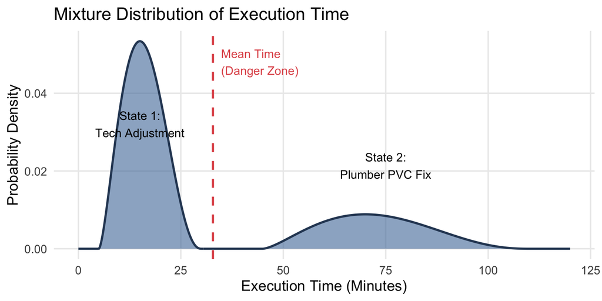

Figure 17: Example of a Bimodal Mixture Distribution. The mathematical ‘average’ time falls in a dead zone, highlighting why stochastic modeling is required for accurate labor planning.

By mapping these mixture distributions across the entire property, we build a comprehensive dictionary of constraints. The complete operational matrix—detailing baseline defect rates, multi-state PERT parameters, material costs, and prerequisite dependencies—is defined in Table 2.

This master configuration encodes tasks into the simulation engine. For example, it explicitly maps the physical handoffs between internal technicians adjusting standard sink drains and licensed plumbers replacing downstream PVC P-traps via vendor flags and scheduling lags.

When using the interactive table below, expanding the arrow at the left of any task reveals the exact time, cost, and probability parameters driving its Monte Carlo realizations.

Table 2: NSPIRE Task Modalities and Execution Constraints. Task categories map to core operational domains: FS (Fire Safety), EL (Electrical), PL (Plumbing), VA (Ventilation & Appliances), DW (Doors, Windows & Millwork), and SU (Surfaces). Clicking on the row arrow will display PERT, cost and decay parameters.

|  | task_id | category | severity | description | prerequisites | p_defect | p_miss_base | p1 | t1_a | t1_m | t1_b | cost1 | p2 | t2_a | t2_m | t2_b | cost2 | vendor2_flag | lag2_min | lag2_max | lockout2_hrs | p3 | t3_a | t3_m | t3_b | cost3 | vendor3_flag | lag3_min | lag3_max | … |
| --- | --- | --- | --- | --- | --- | --- | --- | --- | --- | --- | --- | --- | --- | --- | --- | --- | --- | --- | --- | --- | --- | --- | --- | --- | --- | --- | --- | --- | --- | --- |
| 1 | FS-01 | FS | LT | Smoke Detector | EL-02\|SU-03\|SU-05 | 0.15 | 0.02 | 0.8 | 5 | 10 | 15 | 5 | 0.2 | 10 | 15 | 25 | 25 | False | 0 | 0 | 0 | 0 | 0 | 0 | 0 | 0 | False | 0 | 0 | … |
| 2 | FS-02 | FS | LT | Carbon Monoxide Detector |  | 0.1 | 0.02 | 0.85 | 5 | 10 | 15 | 5 | 0.15 | 10 | 15 | 25 | 35 | False | 0 | 0 | 0 | 0 | 0 | 0 | 0 | 0 | False | 0 | 0 | … |
| 3 | FS-03 | FS | LT | Unit Fire Door Closer | FS-04 | 0.05 | 0.05 | 0.75 | 5 | 10 | 20 | 0 | 0.25 | 15 | 25 | 40 | 65 | False | 0 | 0 | 0 | 0 | 0 | 0 | 0 | 0 | False | 0 | 0 | … |
| 4 | FS-04 | FS | LT | Unit Fire Door Fit/Latch |  | 0.05 | 0.05 | 0.7 | 5 | 10 | 20 | 0 | 0.25 | 15 | 30 | 45 | 150 | False | 0 | 0 | 0 | 0.05 | 0 | 0 | 0 | 800 | True | 7 | 21 | … |
| 5 | FS-05 | FS | LT | Egress Window |  | 0.05 | 0.1 | 0.8 | 10 | 15 | 25 | 5 | 0.2 | 30 | 60 | 90 | 120 | False | 0 | 0 | 0 | 0 | 0 | 0 | 0 | 0 | False | 0 | 0 | … |
| 6 | EL-01 | EL | LT | GFCI Receptacles | EL-02\|SU-03 | 0.1 | 0.05 | 0.85 | 10 | 15 | 25 | 20 | 0.15 | 30 | 60 | 90 | 30 | False | 0 | 0 | 0 | 0 | 0 | 0 | 0 | 0 | False | 0 | 0 | … |
| 7 | EL-02 | EL | LT | Breaker Box |  | 0.05 | 0.02 | 0.9 | 5 | 10 | 15 | 5 | 0.1 | 0 | 0 | 0 | 250 | True | 1 | 3 | 0 | 0 | 0 | 0 | 0 | 0 | False | 0 | 0 | … |
| 8 | EL-03 | EL | STD | Wall Plates &amp; Covers | EL-01\|EL-05\|SU-05 | 0.25 | 0.15 | 0.95 | 5 | 10 | 15 | 2 | 0.05 | 10 | 15 | 25 | 5 | False | 0 | 0 | 0 | 0 | 0 | 0 | 0 | 0 | False | 0 | 0 | … |
| 9 | EL-04 | EL | STD | Light Fixtures | EL-02\|SU-03 | 0.15 | 0.05 | 0.7 | 5 | 10 | 15 | 5 | 0.3 | 20 | 35 | 50 | 45 | False | 0 | 0 | 0 | 0 | 0 | 0 | 0 | 0 | False | 0 | 0 | … |
| 10 | EL-05 | EL | S | Standard Receptacles &amp; Switches | EL-02\|SU-03 | 0.2 | 0.1 | 0.8 | 5 | 10 | 20 | 5 | 0.2 | 15 | 30 | 45 | 25 | False | 0 | 0 | 0 | 0 | 0 | 0 | 0 | 0 | False | 0 | 0 | … |

[output cut: 24 more lines]

## 3.3 Post-Audit Asset Decay

A critical parameter embedded within the master configuration (Table 2) is the baseline decay rate (p_{decay}). In residential properties, a resolved defect does not stay resolved indefinitely. Once a repair is completed and audited at time $t_{end}$, the asset immediately re-enters a state of stochastic deterioration.

We model this defect re-emergence as a Bernoulli (i.e. binary) process over the waiting period $\delta_{decay}$ (the time gap between the completion of the repair and the arrival of the HUD inspector). Given a baseline daily probability of failure $\lambda_{i}$ for task $i$, the probability $P_{redefect}$ that a newly resolved task breaks again before the inspection is:
$$P_{redefect} = 1 - (1 - \lambda_{i,u}^*)^{\delta_{decay}}$$
Crucially, this decay is not uniform across the property. The effective daily probability of failure $\lambda_{i,u}^*$ is coupled with the unit’s latent state $\phi_u$. This mathematical multiplier actively accelerates the re-emergence of defects in high-impact (“dirty”) units:
$$\lambda_{i,u}^* = \lambda_{i} \cdot \phi_u$$
Temporal decay creates an operational constraint. Completeing preparations too early maximizes the decay window ($\delta_{decay}$), inflating the probability that critical life-safety items (like a smoke detector or GFCI) will randomly fail before the inspector arrives. Conversely, starting preparations too late constricts the repair window, creating a labor backlog.

Beyond stochastic time estimates and decay rates, the master configuration table (Table 2) contains one more operational constraint: the prerequisites column. Maintenance work cannot be executed in a random order. To enforce the physical sequence of repairs, the simulation translates these prerequisites into a Directed Acyclic Graph (DAG), defining the sequence of tasks required to prep a unit.

## 3.4 Resource Mapping and Graph Topology (DAG)

Repairs are frequently subject to sequential dependencies. For example, drywall patching cannot occur until underlying plumbing leaks are resolved, and painting must follow the drywall compound’s cure time.

To model this, we organize maintenance tasks into a Directed Acyclic Graph (DAG), that maps out the required order of operations. Each task (a vertex, $V_i$) requires a stochastic execution time $t_i$ and a material cost $m_i$.

```
flowchart LR
    A[Fix Plumbing Leak] --> B[Patch Drywall]
    B --> C[Wait for Compound to Dry]
    C --> D[Paint Wall]

    style A fill:#f9f9f9,stroke:#333,stroke-width:2px
    style B fill:#f9f9f9,stroke:#333,stroke-width:2px
    style C fill:#ffe6cc,stroke:#d79b00,stroke-width:2px,stroke-dasharray: 5 5
    style D fill:#f9f9f9,stroke:#333,stroke-width:2px
```

A simple Directed Acyclic Graph (DAG) illustrating mandatory task sequences.

When applied to the entire NSPIRE catalog, the topological complexity of maintenance routing becomes apparent. In Figure 18, the algorithm scales the size of each node by its out-degree: the volume of downstream tasks that physically depend upon its completion.

Large nodes represent bottlenecks. For example, EL-02 (the Breaker Box) is a prerequisite hub. If this root node is not resolved, it initiates a cascading scheduling freeze, preventing technicians from executing subsequent tasks like GFCI replacements, exhaust fan repairs, or lighting installations.

[interactive chart not shown]

Figure 18: The complete maintenance DAG. Node size indicates bottleneck severity. Hover over any node to view the full task description. Use the top control in the right corner to reset the view. Categories of tasks: FS (Fire Safety), EL (Electrical), PL (Plumbing), VA (Ventilation & Appliances), DW (Doors, Windows & Millwork), and SU (Surfaces)

### Edge Constraints (Operational Laws)

The directed edges connecting these tasks function as operational constraints within the simulation engine.

- **Sequential Precedence** A directed edge $V_A \to V_B$ requires the start time of $B$ to be $\ge$ the end time of $A$.
  - Example: A technician cannot paint a wall before the drywall compound has fully dried.
- **Temporal Blocking** Certain vertices impose a local resource freeze, locking a spatial node for a time interval $\Delta t$.
  - Example: If an external vendor reglazes a tub that physical zone is locked out for a mandatory cure time. The scheduling engine forces labor to re-route to other tasks or units.
- **Mutually Exclusive Pruning** If a higher-order vertex $V_{replace}$ is activated, redundant child vertices $V_{repair}$ are mathematically pruned ($t_{repair} \to 0$).
  - Example: If an upper kitchen cabinet is critically broken and flagged for full replacement, the system instantly cancels minor, redundant adjustments to its hinges or doors, preventing the assignment of unnecessary labor expenditures.

## 3.5 Execution Capacity and Quality Control

Even with a sequenced DAG, execution is bound by strict physical limits: the time available to work, vendor dependence, and human errors.

### Repair Capacity and Vendor Bottlenecks

The model defines a maintenance repair window constrained by $t_{start}$ (commencement of repairs) and $t_{end}$ (completion of repairs and audit). Given a baseline labor capacity $R_{base}$ (hours/unit/day), the total labor capacity $\text{Cap}$ available for the maintenance cycle is linearly proportional to the duration of this window:
$$\text{Cap} = R_{base} \cdot (t_{start} - t_{end})$$
Tasks requiring labor hours $T_{total} > \text{Cap}$ result in a scheduling backlog, forcing the system to abandon lower-severity items to prioritize high-penalty (LT/S) defects.

This capacity is further constrained by tasks requiring external licensing. For example, while a technician handles a sink drain, repairing the downstream PVC P-trap requires a licensed plumber. When a node evaluates to this severe state, internal labor drops to zero ($t_{internal} \to 0$), but a schedule lag is injected based on a Uniform distribution: $L \sim \text{Uniform}(l_{min}, l_{max})$ days. Furthermore, a mandatory spatial lockout is triggered (e.g., a 24-hour cure time after glazing), forcing the DAG to re-route technicians and accelerating the exhaustion of the remaining timeline.

### Human Error and Audit Efficacy

Execution of a task does not guarantee resolution. A task has a baseline physical probability ($p_{err}$) of being missed or improperly repaired. We quantify quality control using a formal internal audit efficacy parameter, $\alpha_\text{audit} \in [0, 1]$, representing the probability that the pre-inspection internal team detects and successfully mitigates a surviving defect.

**Serial Execution (Single Technician)** The probability that a defect survives the initial repair attempt and remains undetected by the audit phase is:
$$P(\text{Survive}) = (1 - \alpha_\text{audit}) \cdot p_{err}$$
**Parallel Execution (Dual Technicians)** Applying the “Four Eyes” principle, independent cross-checking drastically reduces error. The joint probability of both technicians missing the defect becomes:
$$P(\text{Survive}) = (1 - \alpha_\text{audit}) \cdot p_{err}^2$$

## 3.6 Tenant Heterogeneity and Predictive Risk

Asset deterioration is rarely uniform across a property. Baseline probabilities assume a standard deterioration rate, but damage might clusters around specific tenant behaviors.

### The Bimodal Risk of Tenant Behavior

We model unit “cleanliness” as a bimodal state $\phi_u$ for each unit $u$, representing the inherent maintenance burden generated by the tenant. The tenant impact multiplier $\phi_u$ is drawn from a mixture distribution:
$$\phi_u \sim \begin{cases} \phi_{clean}, & \text{with probability } (1 - \pi) \\ \phi_{dirty}, & \text{with probability } \pi \end{cases}$$
Where $\pi$ is the estimated proportion of high-impact units in the property.

Note that the default simulation parameters assume tenant homogeneity. The effect of a two-valued $\phi_u$ is examined only in Section Section 2.6.

### The Danger of Silence (Latent Covariates)

A lack of historical tenant reporting might mask severe deferred maintenance. To account for this, historical service request volume $W_u$ might serve as a proxy to infer the probability that a unit belongs to the high-impact latent state ($\phi_{dirty}$).

We could define the unit-specific probability $\pi_u$ as a logistic function of service requests $W_u$:
$$\pi_u = P(\phi_u = \phi_{dirty} \vert{} W_u) = \text{logit}^{-1}(\alpha - \beta W_u)$$
Where $\alpha$ and $\beta$ are calibrated tuning parameters. For units with extremely low reporting ($W_u \to 0$), the prior probability of being in the “dirty” state dramatically increases, signaling a high likelihood of latent defects.

This feature is **not utilized in this document**. Exploring it would be an interesting exercise but it would require testing with historical tenant data.

### Modeling Tenant Heterogeneity

Let $p$ be the proportion of clean units and $R$ be the severity ratio of a destructive unit (set to $20.0$). The expected defect multipliers for clean units ($\mu_c$) and destructive units ($\mu_d$) must satisfy:

$$p \mu_c + (1 - p) \mu_d = 1.0$$

By substituting $\mu_d = R \mu_c$, we dynamically calculate the baseline multiplier for the clean units for any given tenant mixture:

$$\mu_c = \frac{1}{p + R(1 - p)}$$

Consequently, as destructive tenants are introduced and generate severe defect clusters, standard units become proportionally cleaner to offset them.

## 3.7 Risk Analysis

Moving beyond deterministic score projections, this model quantifies operational risk by evaluating property score as a stochastic process. By leveraging Monte Carlo simulation, we assess not only the expected outcome but the probability of regulatory non-compliance.

### Quantification of Failure Risk

We define the failure event as $S_{eff} < 60$. Due to the non-linear interaction of random unit sampling, defect emergence probabilities, and repair quality, the effective inspection score $S_{eff}$ is a random variable. We estimate the probability of failure ($P_{fail}$) by simulating $K = 1,000$ independent inspection realizations:
$$P_{fail} = \frac{1}{K} \sum_{i=1}^{K} I(S_{eff,i} < 60)$$
where $I(\cdot)$ is the indicator function. This allows the model to map the property’s risk profile against the HUD enforcement threshold, providing an estimation of failure probability.

### Quantifying Volatility

Standard deviation ($\sigma$) and the Coefficient of Variation ($CV = \sigma/\mu$) provide a global measure of dispersion. However, in NSPIRE compliance, the right tail (scores $> 100$) is truncated, and the distribution is often skewed. The primary risk resides in the left tail—the possibility of a “bad day” where HUD sampling captures a concentrated cluster of high-severity defects. To quantify this downside volatility, we define the Tail Drop Metric ($\tau$):
$$\tau = \frac{\text{med} - P_{05}}{\text{med}} \tag{1}$$

Where:

- $\text{med}$ is the median score
- $P_{05}$ is the 5th percentile of the simulated scores.

$\tau$ represents the percentage degradation from expected performance to the worst-case scenario.

A property may exhibit a high median score while maintaining a high $\tau$, identifying it as a “lottery” asset—stable on average, but highly susceptible to non-linear drops in score due to the interaction of unit sampling variance and tenant-driven decay.

The Tail Drop Metric $\tau$ is a systemic output of our model, functionally defined by the interaction of our control and stochastic parameters:
$$\tau = f(n(N), \alpha_\text{audit}, \pi, \phi_{dirty})$$
This sensitivity function captures how variance in the HUD sampling tier $n(N)$, human error in pre-inspection audit ($\alpha_\text{audit}$), and the underlying distribution of tenant impact ($\pi, \phi_{dirty}$) propagate into downside performance risk. Therefore, $\tau$ can be seen as quantifying score uncertainty or volatility.

# 4 References

Dekker, Rommert. 1996. “Applications of Maintenance Optimization Models: A Review and Analysis.” *Reliability Engineering & System Safety* 51 (3): 229–40.

Kelley Jr, James E, and Morgan R Walker. 1959. “Critical-Path Planning and Scheduling.” *IRE Transactions on Engineering Management*, no. 3: 160–73.

Nicolai, Robin P, and Rommert Dekker. 2008. “Optimal Maintenance of Multi-Component Systems: A Review.” In *Complex System Maintenance Handbook*. Springer.

Rubinstein, Reuven Y, and Dirk P Kroese. 2016. *Simulation and the Monte Carlo Method*. John Wiley & Sons.

# Appendix A: Simulation Configuration Parameters

The Monte Carlo engine is driven by four primary configuration files. These files decouple the mathematical logic of the DAG and the simulation from the hardcoded operational assumptions, allowing the framework to be easily adapted to different properties or regulatory contexts.

## A.1 Task Modalities (The DAG Configuration)

The task parameters—including stochastic duration model parameters, material costs, and prerequisite dependencies—are defined in tasks_config.csv. A complete view of these parameters is available in Section 3 (Table 2).

## A.2 Spatial Organization (Floorplans)

The physical layout of the property determines the volume and distribution of task nodes per unit. File floorplans_config.csv maps the specific quantity of each physical asset (e.g., smoke detectors, GFCI receptacles, interior doors) to standard layouts.

Table 3: Unit Configuration Mapping. Defines the quantity of each physical asset present across various floorplan layouts.

| task_id | category | description | Studio | 1BR_1BA | 2BR_1BA | 2BR_2BA | 3BR_2BA |
| --- | --- | --- | --- | --- | --- | --- | --- |
| FS-01 | FS | Smoke Detector | 1 | 2 | 3 | 3 | 4 |
| FS-02 | FS | Carbon Monoxide Detector | 1 | 1 | 1 | 1 | 1 |
| FS-03 | FS | Unit Fire Door Closer | 1 | 1 | 1 | 1 | 1 |
| FS-04 | FS | Unit Fire Door Fit/Latch | 1 | 1 | 1 | 1 | 1 |
| FS-05 | FS | Egress Window | 1 | 2 | 3 | 3 | 4 |
| EL-01 | EL | GFCI Receptacles | 2 | 2 | 2 | 3 | 3 |
| EL-02 | EL | Breaker Box | 1 | 1 | 1 | 1 | 1 |
| EL-03 | EL | Wall Plates &amp; Covers | 6 | 8 | 10 | 12 | 14 |
| EL-04 | EL | Light Fixtures | 4 | 5 | 6 | 8 | 10 |
| EL-05 | EL | Standard Receptacles &amp; Switches | 8 | 10 | 12 | 14 | 16 |

[output cut: 24 more lines]

## A.3 Regulatory Scoring Rubrics

To maintain flexibility for historical comparisons or state-level audits, the scoring logic reads directly from scoring_config.csv. This allows the engine to dynamically swap out the HUD deduction weights. The simulations in this study utilized the NSPIRE weights.

Table 4: Regulatory Scoring Rubrics and Deductions.

| Rubric Name | Severity | Deduction |
| --- | --- | --- |
| NSPIRE | LT | 60.0 |
| NSPIRE | S | 14.8 |
| NSPIRE | MOD | 5.5 |
| NSPIRE | LOW | 2.4 |
| UPCS | LT | 3.0 |
| UPCS | S | 1.5 |
| UPCS | STD | 0.5 |

## A.4 Global Operational Assumptions

Global simulation constraints—such as time limits, labor capacities, and transit friction—are controlled via a master YAML configuration (scenario1.yml). This design allows for rapid sensitivity testing across different macro-operational environments without altering the underlying R source code.

The baseline parameters used as the anchor for the studies in Section 2 are detailed below:

````markdown
```yaml
scenario_name: "Baseline"
description: "Standard NSPIRE scenario with expanded overtime"

temporal_strategy:
  days_before_inspection: 30
  regular_capacity_hours_per_unit: 8
  historical_tickets_lambda: 12

staffing:
  techs_per_unit: 1
  efficiency_multiplier: 1.0
  hourly_rate_internal: 45.0
  max_overtime_hours_per_unit: 4  # Expanded capacity baseline
  overtime_multiplier: 1.5

workflow:
  audit_catch_rate: 0.85
  friction_intra:    # Transit delays within a single unit (minutes)
    min: 2
    mode: 3
    max: 5
  friction_inter:    # Transit delays across different units (minutes)
    min: 10
    mode: 15
    max: 30
```
````

# Appendix B: R code

## B.1 Simulator code

```
%%{init: {'theme': 'base', 'themeVariables': {'background': '#ffffff', 'clusterBkg': '#f8f9fa', 'clusterBorder': '#b0bec5', 'primaryTextColor': '#000000', 'lineColor': '#555555', 'edgeLabelBackground': '#f9fbe7', 'tertiaryTextColor': '#000000'}}}%%

graph TD
    %% Define S4 Classes
    subgraph OOP [S4 Data Structures]
        DAG["<b>InspectionDAG</b><br>Mathematical Graph & Tasks"]
        ENV["<b>InspectionSimulation</b><br>Complete Scenario Environment"]
        ENV ==>|"Contains"| DAG
    end

    %% Define Core Engine
    subgraph Engine [Simulation Engine]
        MC("<b>run_monte_carlo</b><br><i>Master Orchestrator</i>")

        SIM("<b>run_simulation</b><br><i>Defect Generation</i>")
        SCHED("<b>schedule_repairs</b><br><i>Routing & Finance</i>")
        AUDIT("<b>apply_audit_fixes</b><br><i>Quality Control</i>")
        SCORE("<b>calculate_inspection_score</b><br><i>HUD Deductions</i>")

        MC -->|"1. Executes"| SIM
        MC -->|"2. Passes raw defects to"| SCHED
        MC -->|"3. Passes schedule to"| AUDIT
        MC -->|"4. Passes fixed defects to"| SCORE
    end

    %% Define Interactions
    SIM -.->|"Reads Unit Mix & Task Topology"| ENV
    SCHED -.->|"Reads Transit Friction & Capacity"| ENV

    %% Explicitly Style Subgraphs
    style OOP fill:#ffffff,stroke:#cccccc,stroke-width:2px,color:#000000
    style Engine fill:#ffffff,stroke:#cccccc,stroke-width:2px,color:#000000

    %% Explicitly Style Nodes
    style DAG fill:#e1f5fe,stroke:#0288d1,stroke-width:2px,color:#000000
    style ENV fill:#e1f5fe,stroke:#0288d1,stroke-width:2px,color:#000000
    style MC fill:#fff3e0,stroke:#f57c00,stroke-width:2px,color:#000000
    style SIM fill:#f5f5f5,stroke:#9e9e9e,stroke-width:1px,color:#000000
    style SCHED fill:#f5f5f5,stroke:#9e9e9e,stroke-width:1px,color:#000000
    style AUDIT fill:#f5f5f5,stroke:#9e9e9e,stroke-width:1px,color:#000000
    style SCORE fill:#f5f5f5,stroke:#9e9e9e,stroke-width:1px,color:#000000

    %% Explicitly Style Links (Edges)
    linkStyle default stroke:#555555,stroke-width:1px,color:#000000
```

Architecture of the NSPIRE Simulation Framework

```
%%{init: {'theme': 'base', 'themeVariables': {'background': '#ffffff', 'clusterBkg': '#f8f9fa', 'clusterBorder': '#b0bec5', 'primaryTextColor': '#000000', 'lineColor': '#555555', 'edgeLabelBackground': '#f9fbe7', 'tertiaryTextColor': '#000000'}}}%%

graph LR
    %% Inputs
    subgraph Configs [Configuration Files]
        direction TB
        C_TASKS["<b>tasks_config.csv</b>"]
        C_FP["<b>floorplans_config.csv</b>"]
        C_YAML["<b>scenario1.yml</b>"]
        C_SCORE["<b>scoring_config.csv</b>"]
    end

    %% Targets
    subgraph Codebase [Simulation Components]
        direction TB
        DAG["<b>InspectionDAG</b><br>Mathematical Graph & Tasks"]
        ENV["<b>InspectionSimulation</b><br>Complete Scenario Environment"]
        SCORE("<b>calculate_inspection_score</b><br><i>HUD Deductions</i>")
    end

    %% Mappings
    C_TASKS ==>|"Builds"| DAG
    C_FP ==>|"Defines Spatial Units"| ENV
    C_YAML ==>|"Sets Strategies & Constraints"| ENV
    C_SCORE ==>|"Provides Deduction Weights"| SCORE

    %% Subgraph Styling
    style Configs fill:#ffffff,stroke:#cccccc,stroke-width:2px,color:#000000
    style Codebase fill:#ffffff,stroke:#cccccc,stroke-width:2px,color:#000000

    %% File Nodes (Green)
    style C_TASKS fill:#e8f5e9,stroke:#388e3c,stroke-width:2px,color:#000000
    style C_FP fill:#e8f5e9,stroke:#388e3c,stroke-width:2px,color:#000000
    style C_YAML fill:#e8f5e9,stroke:#388e3c,stroke-width:2px,color:#000000
    style C_SCORE fill:#e8f5e9,stroke:#388e3c,stroke-width:2px,color:#000000

    %% Target Nodes (Blue & Grey)
    style DAG fill:#e1f5fe,stroke:#0288d1,stroke-width:2px,color:#000000
    style ENV fill:#e1f5fe,stroke:#0288d1,stroke-width:2px,color:#000000
    style SCORE fill:#f5f5f5,stroke:#9e9e9e,stroke-width:1px,color:#000000

    %% Edge Styling
    linkStyle default stroke:#555555,stroke-width:2px,color:#000000
```

Integration of Configuration Files into the Codebase

Table 5: Core NSPIRE Simulator R Scripts and Architecture Roles

| Script Name | Architecture Role | Description |
| --- | --- | --- |
| InspectionDAG.R | S4 Data Structure | Defines the mathematical graph, ensuring physical prerequisites and task dependencies are rigidly enforced. |
| InspectionSimulation.R | S4 Data Structure | The operational wrapper that combines the DAG, physical floorplans, and YAML constraints into a complete, pre-calculated environment. |
| SimulationEngine.R | Core Engine | The physics and logistics module; handles Beta-PERT stochastic times, defect generation, and context-aware scheduling/transit friction. |
| ScoringEngine.R | Core Engine | The regulatory filter; applies internal quality control (audit catch rates), HUD random sampling protocols, and final score deductions. |
| MonteCarloWrapper.R | Core Engine | The master orchestrator that loops the execution sequence (Generation -> Scheduling -> Audit -> Scoring) across thousands of iterations. |

### B.1.1 InspectionDAG.R

```r
# ==========================================
# 1. DAG Class Definition
# ==========================================

#' InspectionDAG Class
#'
#' An S4 class that represents the mathematical directed acyclic graph (DAG)
#' of inspection tasks and their dependencies. This ensures physical constraints
#' (e.g., drywall must be patched before painting) are rigidly enforced during simulation.
#'
#' @slot tasks_config A \code{data.frame} containing task times, costs, dependencies, and decay probabilities (lambda).
#' @slot adj_list A \code{list} providing a fast-lookup prerequisite adjacency list for the scheduling engine.
#' @slot graph An \code{igraph} object representing the network of task dependencies, used for topological sorting and spatial lockouts.
#' @export
setClass(
  "InspectionDAG",
  slots = list(
    tasks_config = "data.frame",  # Contains task times, dependencies, and p_decay
    adj_list     = "list",        # Fast-lookup prerequisite list
    graph        = "ANY"          # igraph object
  )
)

# ==========================================
# 2. The Constructor Function
# ==========================================

#' Create an Inspection DAG
#'
#' Reads a CSV configuration matrix, validates the workflow dependencies,
#' and constructs an \code{InspectionDAG} object. It explicitly checks for circular
#' dependencies to prevent infinite loops in the maintenance schedule.
#'
#' @param csv_path A character string representing the file path to the tasks configuration CSV.
#' @return An object of class \code{InspectionDAG}.
#' @importFrom methods new
#' @export
create_inspection_dag <- function(csv_path) {
  # Read the CSV matrix containing the master configuration of tasks
  df <- read.csv(csv_path, stringsAsFactors = FALSE, strip.white = TRUE, check.names = FALSE)

  # Ensure NAs are handled uniformly to prevent graph generation errors
  df$prerequisites[is.na(df$prerequisites) | df$prerequisites == "NA"] <- ""

  # Build Adjacency List: Parse the pipe-delimited prerequisites into a list of vectors
  adj <- lapply(df$prerequisites, function(p) {
    if (p == "") return(character(0))
    trimws(unlist(strsplit(p, "\\|")))
  })
  names(adj) <- df$task_id

  # Build igraph Object: Construct the edge list from the adjacency structure
  edges <- character(0)
  for (i in seq_along(adj)) {
    target_node <- names(adj)[i]
    for (prereq_node in adj[[i]]) {
      # Direction is Prerequisite -> Target Node
      edges <- c(edges, prereq_node, target_node)
    }
  }

  # Initialize an empty directed graph and add all vertices (even those without edges)
  g <- igraph::make_empty_graph(directed = TRUE) + igraph::vertices(df$task_id)
  if (length(edges) > 0) {
    g <- g + igraph::edges(edges)
  }

  # Validate Graph Mathematics: Physical operations cannot have circular dependencies
  if (!igraph::is_dag(g)) {
    stop("CRITICAL ERROR: Circular dependencies detected in the CSV. It is not a valid DAG.")
  }

  # Return fully validated S4 Object
  methods::new("InspectionDAG",
               tasks_config = df,
               adj_list = adj,
               graph = g)
}

# ==========================================
# 3. The Custom Show Method
# ==========================================

#' Show method for InspectionDAG
#'
#' Prints a clean console dashboard summary of the DAG's mathematical properties,
#' including root tasks (no prerequisites) and terminal tasks (no downstream dependencies).
#'
#' @param object An \code{InspectionDAG} object.
#' @importFrom methods show
#' @exportMethod show
setMethod("show", "InspectionDAG", function(object) {
  cat("========================================\n")
  cat("          Inspection DAG Object         \n")
  cat("========================================\n")
  cat("Total Tasks (Nodes)   :", nrow(object@tasks_config), "\n")
  cat("Dependencies (Edges)  :", igraph::ecount(object@graph), "\n")
  cat("Graph is Acyclic?     :", igraph::is_dag(object@graph), "\n\n")

  # Find "Root" tasks (in-degree of 0 means they have no prerequisites and can be started immediately)
  in_degrees <- igraph::degree(object@graph, mode = "in")
  roots <- names(in_degrees[in_degrees == 0])
  cat("Independent Root Tasks:", length(roots), "\n")

  # Find "Terminal" tasks (out-degree of 0 means no downstream dependencies rely on them)
  out_degrees <- igraph::degree(object@graph, mode = "out")
  terminals <- names(out_degrees[out_degrees == 0])
  cat("Terminal Tasks        :", length(terminals), "\n")
  cat("========================================\n")
})
```

### B.1.2 InspectionSimulation.R

```r
# ==========================================
# 1. The Simulation Environment Class Definition
# ==========================================

#' InspectionSimulation Class
#'
#' An S4 class representing the complete computational environment for an NSPIRE
#' Monte Carlo simulation. This class acts as the operational wrapper, combining
#' the mathematical DAG with physical building characteristics and temporal strategy.
#'
#' @slot dag An object of class \code{InspectionDAG} representing the task dependencies.
#' @slot floorplans A \code{data.frame} containing the physical item counts per unit archetype.
#' @slot scenario A \code{list} containing the parsed YAML operational strategy parameters (e.g., staffing, friction).
#' @slot building_mix A \code{numeric} vector of normalized probabilities representing the demographic distribution of unit archetypes.
#' @slot topo_nodes A \code{character} vector caching the topological sort of the DAG for rapid, linear scheduling.
#' @slot long_floorplans A \code{data.frame} caching the reshaped, long-format physical items for highly optimized merging during iteration.
#' @export
setClass(
  "InspectionSimulation",
  slots = list(
    dag          = "InspectionDAG", # The mathematical graph
    floorplans   = "data.frame",    # Unit spatial configurations
    scenario     = "list",          # Parsed YAML strategy parameters
    building_mix = "numeric",       # Normalized probabilities for unit archetypes
    topo_nodes   = "character",     # Cached topological sort
    long_floorplans = "data.frame"  # Cached long-format physical items
  )
)

# ==========================================
# 2. The Constructor Function
# ==========================================

#' Create a Simulation Environment
#'
#' Validates and constructs an \code{InspectionSimulation} object from raw configuration files.
#' This constructor performs critical cross-validation to ensure the physical floorplans
#' perfectly align with the DAG prerequisites. It also pre-computes the topological sort
#' and reshapes data structures to drastically reduce computational overhead during
#' the Monte Carlo iterations.
#'
#' @param dag_csv A character string. Path to the tasks configuration CSV file.
#' @param floorplan_csv A character string. Path to the floorplans configuration CSV file.
#' @param yaml_path A character string. Path to the scenario configuration YAML file.
#' @param mix_weights A named numeric vector representing the initial distribution of unit types (e.g., c("1BR" = 10, "2BR" = 40)).
#'
#' @return An object of class \code{InspectionSimulation}.
#' @importFrom methods new
#' @export
create_simulation_env <- function(dag_csv, floorplan_csv, yaml_path, mix_weights) {

  # 1. Instantiate the mathematical DAG object
  my_dag <- create_inspection_dag(dag_csv)

  # 2. Load the physical floorplan item counts
  fp_df <- read.csv(floorplan_csv, stringsAsFactors = FALSE, strip.white = TRUE, check.names = FALSE)

  # Validate that the DAG and Floorplans match perfectly
  # A task cannot exist in the DAG if there is no physical mapping for it in the units
  missing_tasks <- setdiff(my_dag@tasks_config$task_id, fp_df$task_id)
  if (length(missing_tasks) > 0) {
    stop("CRITICAL ERROR: Tasks in DAG are missing from floorplans_config.csv: ",
         paste(missing_tasks, collapse = ", "))
  }

  # Pre-calculate Topological Sort: Done once here to save thousands of graph evaluations during the Monte Carlo loop
  topo_nodes <- names(igraph::topo_sort(my_dag@graph))

  # Pre-shape Floorplans to long format: Melts the wide CSV into a clean entity-attribute structure for vectorized merges
  archetypes <- names(mix_weights)
  long_fp_list <- lapply(archetypes, function(arch) {
    data.frame(
      unit_type = arch,
      task_id = fp_df$task_id,
      item_count = fp_df[[arch]],
      stringsAsFactors = FALSE
    )
  })
  long_fp <- do.call(rbind, long_fp_list)
  # Drop zero-count items to prevent generating phantom tasks in the simulation
  long_fp <- long_fp[long_fp$item_count > 0, ]

  # 3. Load the operational strategy YAML constraints (budget, timeframe, friction parameters)
  if (!file.exists(yaml_path)) {
    stop("CRITICAL ERROR: YAML configuration file not found at ", yaml_path)
  }
  scenario_config <- yaml::read_yaml(yaml_path)

  # 4. Normalize the building mix probabilities (ensure they sum to exactly 1.0)
  if (is.null(names(mix_weights))) {
    stop("CRITICAL ERROR: mix_weights must be a named numeric vector (e.g., c('Type_A'=0.4, 'Type_B'=0.6))")
  }
  mix_weights <- mix_weights / sum(mix_weights)

  # Return the fully validated S4 Object containing all cached configurations
  new("InspectionSimulation",
      dag          = my_dag,
      floorplans   = fp_df,
      scenario     = scenario_config,
      building_mix = mix_weights,
      topo_nodes   = topo_nodes,
      long_floorplans = long_fp)
}

# ==========================================
# 3. The Custom Show Method (Console Dashboard)
# ==========================================

#' Show method for InspectionSimulation
#'
#' Prints a clean, human-readable dashboard summary of the simulation environment parameters.
#' This surfaces the exact financial, temporal, and demographic constraints read from the YAML.
#'
#' @param object An \code{InspectionSimulation} object.
#' @importFrom methods show
#' @exportMethod show
setMethod("show", "InspectionSimulation", function(object) {
  scen <- object@scenario

  # Generate a formatted readout of the operational constraints
  cat("====================================================\n")
  cat("             NSPIRE Simulation Environment          \n")
  cat("====================================================\n")
  cat("Scenario    :", scen$scenario_name, "\n")
  cat("Description :", scen$description, "\n")
  cat("----------------------------------------------------\n")
  cat("Operational Strategy:\n")
  cat("  - Prep Window     :", scen$temporal_strategy$days_before_inspection, "Days Out\n")
  cat("  - Techs per Unit  :", scen$staffing$techs_per_unit, "\n")
  cat("  - Synergy Bonus   :", scen$staffing$efficiency_multiplier, "\n")
  cat("  - Audit Catch Rate:", sprintf("%.1f%%", scen$workflow$audit_catch_rate * 100), "\n")
  cat("----------------------------------------------------\n")
  cat("Financials & Constraints:\n")
  cat("  - Base Rate       : $", sprintf("%.2f", scen$staffing$hourly_rate_internal), "/hr\n", sep="")
  cat("  - Regular Limit   :", scen$temporal_strategy$regular_capacity_hours_per_unit, "hrs/unit\n")
  cat("  - Max Overtime    :", scen$staffing$max_overtime_hours_per_unit, "hrs/unit @",
      scen$staffing$overtime_multiplier, "x Rate\n")
  cat("----------------------------------------------------\n")
  cat("Building Demographics:\n")
  cat("  - Historic Tickets:", scen$temporal_strategy$historical_tickets_lambda, "per year (Average)\n")
  cat("  - Unit Mix        : ")

  # Print the unit mix cleanly (e.g., Type_A: 40%, Type_B: 60%)
  mix_strings <- paste0(names(object@building_mix), ": ",
                        round(object@building_mix * 100, 1), "%")
  cat(paste(mix_strings, collapse = ", "), "\n")
  cat("====================================================\n")
})
```

### B.1.3 SimulationEngine.R

```r
# ==========================================
# 1. Stochastic Helpers
# ==========================================

#' Beta-PERT Random Number Generator (Vectorized)
#'
#' Generates random execution times based on a 3-point estimation technique
#' widely used in project management. The function is fully vectorized, allowing
#' it to sample thousands of tasks simultaneously without slow `for` loops.
#'
#' @param n Integer. Number of random draws to generate.
#' @param a Numeric vector. The optimistic (minimum) time estimate.
#' @param m Numeric vector. The most likely (mode) time estimate.
#' @param b Numeric vector. The pessimistic (maximum) time estimate.
#' @return A numeric vector of simulated execution times.
#' @export
rpert <- function(n, a, m, b) {
  res <- numeric(n)

  # Handle deterministic edge cases where min == max (no variance)
  fixed_idx <- (a == b)
  if (any(fixed_idx)) res[fixed_idx] <- a[fixed_idx]

  # Calculate Beta shape parameters and draw for variable tasks
  var_idx <- !fixed_idx
  if (any(var_idx)) {
    a_v <- a[var_idx]; m_v <- m[var_idx]; b_v <- b[var_idx]
    alpha <- 1 + 4 * ((m_v - a_v) / (b_v - a_v))
    beta_param  <- 1 + 4 * ((b_v - m_v) / (b_v - a_v))
    res[var_idx] <- a_v + stats::rbeta(sum(var_idx), alpha, beta_param) * (b_v - a_v)
  }
  return(res)
}

#' Generate Building Demographics
#'
#' Generates a simulated building by sampling unit archetypes based on
#' the normalized demographic probabilities defined in the scenario YAML.
#'
#' @param sim_env An \code{InspectionSimulation} object.
#' @param total_units Integer. Total number of apartments to generate.
#' @return A character vector of unit archetypes (e.g., c("1BR", "2BR", "1BR")).
#' @export
generate_building <- function(sim_env, total_units) {
  archetypes <- names(sim_env@building_mix)
  probs <- as.numeric(sim_env@building_mix)
  sample(x = archetypes, size = total_units, replace = TRUE, prob = probs)
}

# ==========================================
# 2. Core Physics & Defect Generation
# ==========================================

#' Run NSPIRE Inspection Simulation (Physics Engine)
#'
#' Generates the raw physical defects for a building. It applies spatial heterogeneity
#' (the tenant "Lottery Effect") by creating clean and dirty units, ensuring that the
#' overall building maintains a strict "Conservation of Defects" across iterations.
#'
#' @param sim_env An \code{InspectionSimulation} object.
#' @param total_units Integer. Number of units to simulate (default: 100).
#' @param seed Integer. Optional random seed for reproducibility.
#' @return A \code{data.frame} of instantiated physical defects requiring repair.
#' @export
run_simulation <- function(sim_env, total_units = 100, seed = NULL) {
  if (!is.null(seed)) set.seed(seed)

  building_units <- generate_building(sim_env, total_units)
  scen <- sim_env@scenario

  # Establish spatial heterogeneity constraints
  clean_prop <- scen$tenant_factors$clean_proportion %||% 0.80

  # Use a multiplier ratio instead of hardcoded absolute means for flexibility
  severity_ratio <- scen$tenant_factors$dirty_severity_ratio %||% 5.0

  # Dynamically balance the means to enforce "Conservation of Defects".
  # If destructive units are extremely severe, standard units must become
  # mathematically cleaner to keep the global expected severity fixed at 1.0.
  clean_mean <- 1.0 / (clean_prop + severity_ratio * (1 - clean_prop))
  dirty_mean <- clean_mean * severity_ratio

  # Assign units to binary latent states (Clean vs. Dirty)
  is_clean <- stats::runif(total_units) <= clean_prop
  tenant_factors <- numeric(total_units)

  # Scale Standard Deviations proportionally to prevent pmax() from biasing the global mean
  if(any(is_clean)) {
    tenant_factors[is_clean] <- pmax(0.01, stats::rnorm(sum(is_clean), mean = clean_mean, sd = 0.2 * clean_mean))
  }
  if(any(!is_clean)) {
    tenant_factors[!is_clean] <- pmax(0.01, stats::rnorm(sum(!is_clean), mean = dirty_mean, sd = 0.2 * dirty_mean))
  }

  # Build the base unit dataframe
  units_df <- data.frame(
    unit_id = paste0("Unit_", seq_along(building_units)),
    unit_type = building_units,
    tenant_factor = tenant_factors,
    stringsAsFactors = FALSE
  )

  # Merge units with the long-format floorplan to spawn physical items inside the units
  long_fp <- sim_env@long_floorplans
  master <- merge(units_df, long_fp, by = "unit_type", all.x = TRUE)
  # Expand the dataframe so every individual physical item gets its own row
  master <- master[rep(seq_len(nrow(master)), master$item_count), ]

  # Attach task probabilities, execution times, and costs from the DAG config
  tasks <- sim_env@dag@tasks_config[, c("task_id", "category", "severity", "p_defect", "p_miss_base", "t1_a", "t1_m", "t1_b", "cost1")]
  master <- merge(master, tasks, by = "task_id", all.x = TRUE)

  # Evaluate stochastic failure: Does the item break? (Cap probability at 1.0)
  adjusted_p_defect <- pmin(1.0, master$p_defect * master$tenant_factor)
  is_defective <- stats::runif(nrow(master)) < adjusted_p_defect

  # Filter down to only the broken items
  defects <- master[is_defective, ]

  # Edge case handling: Pristine building with zero defects
  if(nrow(defects) == 0) {
    return(data.frame(unit_id=character(), unit_type=character(), task_id=character(),
                      category=character(), severity=character(), tenant_factor=numeric(),
                      p_defect=numeric(), is_caught=logical(),
                      repair_time_mins=numeric(), material_cost=numeric()))
  }

  # Generate task-specific stochastic outcomes
  defects$is_caught <- stats::runif(nrow(defects)) >= defects$p_miss_base
  defects$repair_time_mins <- round(rpert(nrow(defects), defects$t1_a, defects$t1_m, defects$t1_b), 2)

  # Package the final raw defect payload
  results_df <- data.frame(
    unit_id = defects$unit_id, unit_type = defects$unit_type, task_id = defects$task_id,
    category = defects$category, severity = defects$severity, tenant_factor = defects$tenant_factor,
    p_defect = defects$p_defect, is_caught = defects$is_caught,
    repair_time_mins = defects$repair_time_mins, material_cost = defects$cost1,
    stringsAsFactors = FALSE
  )

  # Sort cleanly by Unit ID for downstream scheduling
  unit_nums <- as.numeric(gsub("Unit_", "", results_df$unit_id))
  results_df <- results_df[order(unit_nums, results_df$task_id), ]
  rownames(results_df) <- NULL

  return(results_df)
}

# ==========================================
# 3. Logistics & Execution Engine
# ==========================================

#' Schedule Repairs with Context-Aware Transit Friction
#'
#' Evaluates the raw defects, sorts them by spatial layout and DAG topology,
#' and calculates the operational schedule. It natively injects stochastic transit
#' friction based on whether a technician is transitioning between tasks in the same
#' unit or packing up to move to a new apartment.
#'
#' @details This function is heavily vectorized to calculate complex financial straddles
#' (e.g., a task starting in regular time but finishing in overtime) across thousands
#' of tasks instantly.
#'
#' @param defects A data.frame of raw defects generated by run_simulation.
#' @param sim_env An \code{InspectionSimulation} environment object.
#' @param t_prep_days Numeric. Optional override for the timeline constraints in the YAML.
#' @return A data.frame enriched with scheduling cumulative times, friction penalties, and financial calculations.
#' @export
schedule_repairs <- function(defects, sim_env, t_prep_days = NULL) {
  if (nrow(defects) == 0) return(data.frame())

  # 1. Sort by topological order, grouped strictly by unit to minimize travel
  defects$topo_rank <- match(defects$task_id, sim_env@topo_nodes)
  defects <- defects[order(defects$unit_id, defects$topo_rank), ]

  # 2. Extract Scenario Constraints (with bulletproof fallbacks to prevent crashes)
  scen <- sim_env@scenario

  # Helper to safely extract values that might be NULL or length 0
  safe_extract <- function(x, default) {
    if (is.null(x) || length(x) == 0 || is.na(x)) default else x
  }

  reg_hours <- safe_extract(scen$temporal_strategy$regular_capacity_hours_per_unit, 8)
  ot_hours  <- safe_extract(scen$staffing$max_overtime_hours_per_unit, 4)
  techs     <- safe_extract(scen$staffing$techs_per_unit, 1)
  base_rate <- safe_extract(scen$staffing$hourly_rate_internal, 45) / 60
  ot_rate   <- base_rate * safe_extract(scen$staffing$overtime_multiplier, 1.5)

  daily_reg_mins <- reg_hours * 60
  daily_ot_mins  <- ot_hours * 60

  # Allow dynamic override for sensitivity sweeps, fallback to YAML
  days_available <- safe_extract(t_prep_days, safe_extract(scen$temporal_strategy$days_before_inspection, 30))

  total_reg_capacity <- daily_reg_mins * days_available * techs
  total_ot_capacity  <- daily_ot_mins * days_available * techs
  absolute_capacity  <- total_reg_capacity + total_ot_capacity

  # 3. Vectorized Context-Aware Transit Friction
  n_tasks <- nrow(defects)

  # Determine if the tech is moving to a new unit (TRUE) or staying in the same unit (FALSE)
  # The very first task of the simulation is always a "new unit" dispatch.
  is_new_unit <- c(TRUE, defects$unit_id[-1] != defects$unit_id[-n_tasks])

  # Extract friction distribution parameters from scenario with fallbacks
  f_intra <- scen$workflow$friction_intra
  f_inter <- scen$workflow$friction_inter

  # Generate stochastic delay distributions for the entire batch at once
  friction_intra <- rpert(
    n = n_tasks,
    a = f_intra$min,
    m = f_intra$mode,
    b = f_intra$max
  )

  friction_inter <- rpert(
    n = n_tasks,
    a = f_inter$min,
    m = f_inter$mode,
    b = f_inter$max
  )

  # Assign rigid micro-delays based on the technician's context (same unit vs new unit)
  defects$friction_mins <- ifelse(is_new_unit, friction_inter, friction_intra)

  # Calculate cumulative schedule instantly using vectorized cumsum
  task_total_time <- defects$friction_mins + defects$repair_time_mins
  defects$cumulative_time_mins <- cumsum(task_total_time)

  # 4. Vectorized Financial & Backlog Thresholds
  defects$is_overtime <- defects$cumulative_time_mins > total_reg_capacity
  defects$is_backlogged <- defects$cumulative_time_mins > absolute_capacity

  # 5. Vectorized Billing Calculations
  end_time <- defects$cumulative_time_mins
  start_time <- end_time - task_total_time

  # Pre-calculate pure scenarios
  cost_reg <- task_total_time * base_rate
  cost_ot <- task_total_time * ot_rate

  # Calculate straddle scenario (task starts in regular hours, ends in overtime)
  reg_time_straddle <- total_reg_capacity - start_time
  ot_time_straddle <- task_total_time - reg_time_straddle
  cost_straddle <- (reg_time_straddle * base_rate) + (ot_time_straddle * ot_rate)

  # Apply billing logic safely via nested ifelse
  defects$labor_cost <- ifelse(
    end_time <= total_reg_capacity, cost_reg,
    ifelse(start_time >= total_reg_capacity, cost_ot, cost_straddle)
  )

  # Isolate just the overtime premium/spend for reporting
  defects$overtime_cost <- ifelse(
    end_time <= total_reg_capacity, 0,
    ifelse(start_time >= total_reg_capacity, cost_ot, ot_time_straddle * ot_rate)
  )

  # Zero out costs for backlogged items (abandoned work incurs no labor expense)
  defects$labor_cost[defects$is_backlogged] <- 0
  defects$overtime_cost[defects$is_backlogged] <- 0

  return(defects)
}

# Fallback helper operator for null checking
`%||%` <- function(a, b) if (!is.null(a)) a else b
```

### B.1.4 ScoringEngine.R

```r
# ==========================================
# 1. Regulatory Sampling
# ==========================================

#' Get NSPIRE Sample Size
#'
#' Retrieves the HUD-mandated number of units to inspect based on the total
#' property size. This discrete step function drives the variance of the
#' "Lottery Effect" in small to mid-sized properties.
#'
#' @param total_units Integer. The total number of apartments in the property.
#' @return Integer. The specific number of units the inspector will randomly sample.
#' @export
get_nspire_sample_size <- function(total_units) {
  if (total_units <= 5) return(total_units)
  if (total_units <= 7) return(6)
  if (total_units == 8) return(7)
  if (total_units <= 10) return(8)
  if (total_units <= 12) return(9)
  if (total_units <= 14) return(10)
  if (total_units <= 16) return(11)
  if (total_units <= 18) return(12)
  if (total_units <= 21) return(13)
  if (total_units <= 24) return(14)
  if (total_units <= 27) return(15)
  if (total_units <= 30) return(16)
  if (total_units <= 35) return(17)
  if (total_units <= 39) return(18)
  if (total_units <= 45) return(19)
  if (total_units <= 51) return(20)
  if (total_units <= 59) return(21)
  if (total_units <= 67) return(22)
  if (total_units <= 78) return(23)
  if (total_units <= 92) return(24)
  if (total_units <= 110) return(25)
  return(32)
}

# ==========================================
# 2. Quality Control & Asset Decay
# ==========================================

#' Apply Internal Pre-Inspection Audit
#'
#' Simulates the internal quality assurance process and the subsequent
#' post-prep temporal decay. It determines if a defect is successfully caught
#' and fixed by the team, and whether that fixed item randomly re-breaks
#' before the HUD inspector arrives.
#'
#' @param defects_df A \code{data.frame} of scheduled defects.
#' @param audit_catch_rate Numeric [0, 1]. Probability that the internal team detects and fixes a defect.
#' @param t_end Integer. The number of days between the completion of repairs and the actual inspection date.
#' @param seed Integer. Optional random seed for reproducibility.
#' @return A \code{data.frame} with added logical flags: \code{caught_in_audit} and \code{rebroke_before_inspection}.
#' @export
apply_audit_fixes <- function(defects_df, audit_catch_rate, t_end = 0, seed = NULL) {
  if (!is.null(seed)) set.seed(seed)
  if (nrow(defects_df) == 0) {
    defects_df$caught_in_audit <- logical(0)
    defects_df$rebroke_before_inspection <- logical(0)
    return(defects_df)
  }

  # Ensure we respect the workforce backlog limits from the logistics engine
  is_backlogged <- defects_df$is_backlogged
  if (is.null(is_backlogged)) is_backlogged <- rep(FALSE, nrow(defects_df))

  # A defect can only be "caught and fixed" if it is NOT stuck in the backlog.
  # If capacity ran out, the item is mathematically abandoned.
  defects_df$caught_in_audit <- (stats::runif(nrow(defects_df)) <= audit_catch_rate) & !is_backlogged

  # Calculate Stochastic Decay: The probability that a fixed item re-breaks.
  # This scales the baseline annual probability down to a daily rate, amplified by tenant behavior.
  daily_fail_rate <- pmin(1.0, (defects_df$p_defect / 365) * defects_df$tenant_factor)
  p_rebreak <- 1 - (1 - daily_fail_rate)^t_end

  # Evaluate decay only for items that were actually fixed during the audit
  is_fixed <- defects_df$caught_in_audit
  rebroke <- rep(FALSE, nrow(defects_df))
  if (any(is_fixed)) {
    rebroke[is_fixed] <- stats::runif(sum(is_fixed)) < p_rebreak[is_fixed]
  }

  defects_df$rebroke_before_inspection <- rebroke
  return(defects_df)
}

# ==========================================
# 3. HUD Scoring Protocol
# ==========================================

#' Calculate Official Inspection Score
#'
#' Executes the regulatory scoring protocol. It randomly samples the building,
#' identifies the active defects within that sample, merges them against the
#' regulatory deduction weights, and outputs the final mathematical score.
#'
#' @param defects_df A \code{data.frame} of defects processed by the audit engine.
#' @param scoring_csv Character. Path to the configuration file containing defect weights.
#' @param rubric Character. The regulatory rubric to apply (default: "NSPIRE").
#' @param starting_score Numeric. The maximum possible score (default: 100).
#' @param total_units_in_building Integer. Used to calculate the denominator for sampling deductions.
#' @return A list containing \code{final_score} and \code{total_deductions}.
#' @export
calculate_inspection_score <- function(defects_df, scoring_csv, rubric = "NSPIRE", starting_score = 100, total_units_in_building = 50) {
  # Load and filter the deduction weights dictionary
  scoring_df <- read.csv(scoring_csv, stringsAsFactors = FALSE, strip.white = TRUE)
  rubric_df <- scoring_df[scoring_df$rubric_name == rubric, ]

  # Fast exit for a perfect building
  if (nrow(defects_df) == 0) return(list(final_score = starting_score, total_deductions = 0))

  # 1. Execute Random Spatial Sampling (The "Lottery")
  sample_size <- get_nspire_sample_size(total_units_in_building)
  all_possible_units <- paste0("Unit_", 1:total_units_in_building)
  inspected_units <- sample(all_possible_units, size = sample_size, replace = FALSE)

  # Safely handle missing flags just in case the audit step was bypassed
  defects_df$caught_in_audit <- defects_df$caught_in_audit %||% FALSE
  defects_df$rebroke_before_inspection <- defects_df$rebroke_before_inspection %||% FALSE

  # 2. Determine True Active State
  # An item is broken if it was NEVER caught, OR if it was caught but re-broke over time.
  is_active_defect <- !defects_df$caught_in_audit | defects_df$rebroke_before_inspection

  # Check if the defect falls inside the units randomly chosen by the inspector
  in_sample <- defects_df$unit_id %in% inspected_units

  # Filter down to the exact items the inspector actually writes up
  score_hits <- defects_df[is_active_defect & defects_df$is_caught & in_sample, ]

  if (nrow(score_hits) == 0) return(list(final_score = starting_score, total_deductions = 0))

  # 3. Calculate Deductions
  # Join the active defects with the HUD penalty weights based on severity
  itemized <- merge(score_hits, rubric_df[, c("severity", "deduction")], by = "severity", all.x = TRUE)
  itemized$deduction[is.na(itemized$deduction)] <- 0

  # Sum the raw penalties and divide by the sample size (per NSPIRE mathematical rules)
  total_deductions <- sum(itemized$deduction)
  final_score <- max(0, starting_score - (total_deductions / sample_size))

  return(list(final_score = final_score, total_deductions = total_deductions))
}

# Internal Helper: Null-coalescing operator for clean fallback assignments
`%||%` <- function(a, b) if (!is.null(a)) a else b
```

### B.1.5 MonteCarloWrapper.R

```r
#' Orchestrator for NSPIRE Monte Carlo Simulation
#'
#' Executes thousands of "virtual inspections" by repeatedly simulating property decay,
#' scheduling maintenance, applying internal audits, and calculating HUD scores.
#' This function acts as the central hub, passing data sequentially through the
#' four functional pillars of the simulation engine.
#'
#' @param n_iterations Integer. The number of Monte Carlo simulations to execute (default: 1000).
#' @param sim_env An \code{InspectionSimulation} object. The validated environment containing the DAG, floorplans, and YAML parameters.
#' @param score_csv Character. File path to the CSV defining the regulatory scoring deduction weights.
#' @param rubric Character. The specific scoring rubric to use from the scoring configuration (default: "NSPIRE").
#' @param total_units Integer. The total number of apartments in the simulated building (default: 50).
#' @param audit_catch_rate Numeric. The probability [0, 1] that the internal team detects and fixes a defect (default: 0.8).
#' @param t_start Integer. The number of days of notice provided prior to the inspection (prep window start).
#' @param t_end Integer. The number of days before the inspection that maintenance ceases (prep window end).
#' @param seed Integer. Optional random seed for deterministic reproducibility across simulation runs.
#' @param save_raw Logical. If TRUE, saves the full raw defect data frame for every iteration. Use with caution as high \code{n_iterations} will consume massive memory.
#'
#' @return A list containing two elements: \code{summary} (a data.frame of aggregated simulation statistics like score, labor cost, and backlog) and \code{raw} (a list of raw defect frames, if requested).
#' @export
run_monte_carlo <- function(n_iterations = 1000, sim_env, score_csv, rubric = "NSPIRE",
                            total_units = 50, audit_catch_rate = 0.8,
                            t_start = 30, t_end = 5, seed = NULL, save_raw = FALSE) {

  # Set the global seed once for the entire ensemble to guarantee reproducibility
  if (!is.null(seed)) set.seed(seed)

  # Execute the core Monte Carlo loop across n_iterations using a highly optimized lapply
  all_iterations <- lapply(1:n_iterations, function(i) {

    # 1. Defect Generation: Roll the stochastic dice to create the raw physical baseline
    raw_defects <- run_simulation(sim_env, total_units = total_units)

    # 2. Schedule & Route: Apply physical constraints (DAG), transit friction, and labor limits
    # The available repair window is the difference between start notice and prep completion
    scheduled <- schedule_repairs(raw_defects, sim_env, t_prep_days = max(1, t_start - t_end))

    # 3. Audit & Fix: Apply quality control and simulate post-prep temporal decay
    # (BUG FIX: Ensure we use 'scheduled' so that backlogged items cannot magically be audited/fixed)
    audited <- apply_audit_fixes(scheduled, audit_catch_rate, t_end = t_end)

    # 4. Final Scoring: Run the HUD random sampling protocol and calculate the regulatory outcome
    score_report <- calculate_inspection_score(audited, score_csv, rubric = rubric,
                                               total_units_in_building = total_units)

    # Package the iteration results into a standardized vector for fast matrix binding later
    return(list(
      summary = c(score = score_report$final_score,
                  labor = sum(scheduled$repair_time_mins) / 60,
                  total_labor_cost = sum(scheduled$labor_cost),
                  overtime_cost = sum(scheduled$overtime_cost),
                  backlog = sum(scheduled$is_backlogged)),
      raw_defects = if (save_raw) audited else NULL
    ))

  })

  # Aggregate summary matrix: Collapse the list of summary vectors into a single dataframe
  summary_mat <- do.call(rbind, lapply(all_iterations, `[[`, "summary"))
  df_results <- as.data.frame(summary_mat)

  # If forensic raw data was requested, extract and combine it into a list
  raw_list <- if (save_raw) lapply(all_iterations, `[[`, "raw_defects") else NULL

  return(list(summary = df_results, raw = raw_list))
}
```

## B.2 Execution Scripts and Utilities

Table 6: Execution Scripts and Utilities

| Script Name | Architecture Role | Description |
| --- | --- | --- |
| Tools.R | Operational Logic | Houses the prescriptive find_required_capacity binary search algorithm, decoupling labor limits from scoring to strictly target backlog probability. |
| SensitivityAnalysis.R | Analysis Suite | The dispatcher and observables calculator; extracts comprehensive distribution metrics (e.g., tail drops, costs) when sweeping parameters like audit rate or prep time. |
| Decay.R | Execution Script | Maps the exponential failure risk of the ‘Too Early’ penalty by sweeping the post-prep idle window (t_end). |
| TenantMix.R | Execution Script | A high-volume (100k iteration) batched script designed to stabilize extreme tail metrics and quantify the spatial clustering ‘Lottery Effect.’ |
| RunSolver.R | Execution Script | Inverts the simulation to answer prescriptive staffing questions, calling the binary search tool to map required labor against a shrinking timeline. |
| Transit.R | Execution Script | Executes paired simulations to quantify the 34% ‘Operational Reality Gap’, comparing frictionless ideal execution against realistic ground execution. |
| Visualization.R | Utility Script | Provides helper functions, dynamic boundary highlighting, and strict semantic color palettes to generate consistent report figures. |

### B.2.1 Tools.R

```r
#' Prescriptive Analytics: Find Required Tech Headcount (Capacity Solver)
#'
#' Uses a high-speed binary search wrapped around the Monte Carlo engine to find
#' the minimum number of technicians required to clear the known work queue.
#' It targets the probability of task backlog, decoupling labor limits from QA limits.
#'
#' @param sim_env The InspectionSimulation environment
#' @param score_csv Path to the scoring configuration CSV
#' @param t_start_values Numeric vector of prep days to evaluate (e.g., seq(5, 25, by=2))
#' @param target_p_backlog The maximum acceptable risk of incomplete work (e.g., 0.01 for 1%)
#' @param max_techs The upper bound for the binary search
#' @param total_units Number of units in the building to simulate
#' @param n_iterations Number of Monte Carlo iterations per step
#' @param audit_catch_rate Fixed audit efficacy to test under
#'
#' @return A data.frame mapping t_start to required_techs and achieved backlog risk
#' @export
find_required_capacity <- function(sim_env, score_csv, t_start_values,
                                   target_p_backlog = 0.01, max_techs = 30,
                                   total_units = 50, n_iterations = 500,
                                   audit_catch_rate = 0.85) {

  results_list <- list()

  cat(sprintf("\n=== Starting Prescriptive Capacity Solver ===\n"))
  cat(sprintf("Objective: Eliminate Labor Bottlenecks\n"))
  cat(sprintf("Target: P(Backlog > 0) <= %.1f%%\n", target_p_backlog * 100))

  for (t_start in t_start_values) {
    cat(sprintf("\nEvaluating t_start = %d days...\n", t_start))

    low <- 1
    high <- max_techs
    best_techs <- NA
    best_p_backlog <- NA

    # Fast Binary Search (Safe now because P(Backlog) monotonically decreases to 0)
    while (low <= high) {
      mid_techs <- floor((low + high) / 2)
      cat(sprintf("  Testing %d techs... ", mid_techs))

      # Temporarily override the tech capacity in a cloned environment
      temp_env <- sim_env
      temp_env@scenario$staffing$techs_per_unit <- mid_techs

      # Run Monte Carlo for this specific configuration
      mc_res <- run_monte_carlo(
        n_iterations = n_iterations,
        sim_env = temp_env,
        score_csv = score_csv,
        total_units = total_units,
        audit_catch_rate = audit_catch_rate,
        t_start = t_start,
        save_raw = FALSE # Keep memory usage light
      )

      # Calculate empirical probability that ANY tasks were left backlogged
      p_backlog <- mean(mc_res$summary$backlog > 0)
      cat(sprintf("Backlog Risk = %.1f%%\n", p_backlog * 100))

      if (p_backlog <= target_p_backlog) {
        # We achieved the capacity target! Can we do it with fewer techs?
        best_techs <- mid_techs
        best_p_backlog <- p_backlog
        high <- mid_techs - 1 # Search lower half
      } else {
        # We are leaving work unfinished. We need more techs.
        low <- mid_techs + 1 # Search upper half
      }
    }

    # Store the results
    if (is.na(best_techs)) {
      cat(sprintf("  [!] WARNING: Target unattainable even with %d techs.\n", max_techs))
    } else {
      cat(sprintf("  -> Optimal Capacity: %d techs\n", best_techs))
    }

    results_list[[length(results_list) + 1]] <- data.frame(
      t_start = t_start,
      required_techs = ifelse(is.na(best_techs), max_techs, best_techs),
      achieved_p_backlog = ifelse(is.na(best_p_backlog), 1.0, best_p_backlog)
    )
  }

  final_df <- do.call(rbind, results_list)
  cat("\n=== Solver Complete ===\n")
  return(final_df)
}
```

### B.2.2 SensitivityAnalysis.R

```r
# ==================================================
# 1. Sensitivity Runner, for audit_rate and t_start
# ==================================================

#' Run Sensitivity Analysis with Exhaustive Observables
#'
#' Executes a batch of Monte Carlo simulations across a specified parameter range.
#' For each parameter step, it calculates a set of distributional
#' metrics (including Tail Drop, Backlog Probability, and Compliance Risk) and
#' extracts the raw density objects required for downstream ridge plotting.
#'
#' @param sim_env An \code{InspectionSimulation} object establishing the baseline environment.
#' @param score_csv Character. Path to the regulatory scoring config file.
#' @param param_name Character. String identifier for the parameter to sweep (e.g., "audit_rate", "t_start").
#' @param param_values Numeric vector. The sequence of values to test across the sweep.
#' @param save_raw Logical. If TRUE, saves the raw defect forensic files to disk (default: FALSE).
#' @param ... Additional arguments passed dynamically to \code{run_monte_carlo}.
#' @return A \code{data.frame} where each row represents the exhaustive metrics for a single parameter step.
#' @export
run_sensitivity_analysis <- function(sim_env, score_csv, param_name, param_values, save_raw = FALSE, ...) {

  # Ensure the directory structure exists to catch I/O file drops
  base_dir <- file.path("results", "sensitivity", param_name)
  if (!dir.exists(base_dir)) dir.create(base_dir, recursive = TRUE)

  # Execute the sweep across specified parameter values
  results_list <- lapply(param_values, function(val) {
    cat(sprintf("Running Analysis: %s = %f\n", param_name, val))

    current_env <- sim_env
    wrapper_args <- list(...)

    # 1. Parameter Dispatcher: Dynamically mutate the environment or wrapper args based on the target study
    switch(param_name,
           "decay_rate" = { current_env@scenario$decay_rate <- val },
           "tenant_heterogeneity" = { current_env@scenario$tenant_factors$clean_proportion <- val },
           "audit_rate" = { wrapper_args$audit_catch_rate <- val },
           "t_start"    = { wrapper_args$t_start <- val },
           "t_end"      = { wrapper_args$t_end <- val },
           stop(sprintf("Parameter '%s' not defined in dispatcher.", param_name))
    )

    # 2. Execution: Monte Carlo ensemble for this specific parameter state
    mc_out <- do.call(run_monte_carlo, c(list(sim_env = current_env, score_csv = score_csv, save_raw = save_raw), wrapper_args))

    # 3. Save Raw Iteration Data
    # Save the 1,000 summary rows for this specific step
    saveRDS(mc_out$summary, file = file.path(base_dir, paste0("summary_", val, ".rds")))

    if (save_raw) {
      saveRDS(mc_out$raw, file = file.path(base_dir, paste0("raw_full_", val, ".rds")))
    }

    # Extract raw scores to calculate the smooth density function for the ridge plots
    scores_raw <- unlist(mc_out$summary$score)

    # Dynamically pad the density bounds so the graphical tails don't clip at exactly 0 or 100
    min_bound <- max(0, min(scores_raw) - 2)
    max_bound <- min(100, max(scores_raw) + 2)
    score_density <- density(
      scores_raw,
      from = min_bound,
      to = max_bound,
      n = 512
    )

    # Cache the density object for Quarto rendering
    density_filename <- sprintf("score_density_%s.rds", val)
    saveRDS(score_density, file = file.path(base_dir, paste0("score_density_", val, ".rds")))

    # 4. Exhaustive Observables Calculation
    # Extract the raw vectors to compute the statistical moments
    scores <- mc_out$summary$score
    labor <- mc_out$summary$labor
    labor_cost <- mc_out$summary$total_labor_cost
    overtime <- mc_out$summary$overtime_cost
    backlog <- mc_out$summary$backlog

    med_score <- median(scores)
    p05_score <- quantile(scores, 0.05, names = FALSE)
    mean_score <- mean(scores)

    # Construct the metric matrix
    res <- data.frame(
      param_val = val,

      # --- Score Distribution ---
      score_mean = mean_score,
      score_sd = sd(scores),
      score_min = min(scores),
      score_p01 = quantile(scores, 0.01, names = FALSE),
      score_p05 = p05_score,       # The 5th percentile "Value at Risk"
      score_p10 = quantile(scores, 0.10, names = FALSE),
      score_p25 = quantile(scores, 0.25, names = FALSE),
      score_median = med_score,
      score_p75 = quantile(scores, 0.75, names = FALSE),
      score_p90 = quantile(scores, 0.90, names = FALSE),
      score_p95 = quantile(scores, 0.95, names = FALSE),
      score_p99 = quantile(scores, 0.99, names = FALSE),
      score_max = max(scores),

      # --- Risk & Tail Metrics ---
      tail_drop_median = (med_score - p05_score) / med_score, # 'tau' metric from the report
      tail_drop_mean = (mean_score - p05_score) / mean_score,
      fail_risk_60 = mean(scores < 60),                       # Probability of regulatory failure
      critical_fail_risk_30 = mean(scores < 30),

      # --- Labor & Time ---
      labor_hours_mean = mean(labor),
      labor_hours_median = median(labor),
      labor_hours_p95 = quantile(labor, 0.95, names = FALSE),

      # --- Financial Cost ---
      total_cost_mean = mean(labor_cost),
      total_cost_median = median(labor_cost),
      total_cost_p95 = quantile(labor_cost, 0.95, names = FALSE),
      total_cost_max = max(labor_cost),

      # --- Overtime Metrics ---
      overtime_mean = mean(overtime),
      overtime_median = median(overtime),
      overtime_p95 = quantile(overtime, 0.95, names = FALSE),
      overtime_prob = mean(overtime > 0),                     # Likelihood of breaking regular hours

      # --- Backlog Metrics ---
      backlog_mean = mean(backlog),
      backlog_median = median(backlog),
      backlog_p95 = quantile(backlog, 0.95, names = FALSE),
      backlog_prob = mean(backlog > 0)                        # Likelihood of capacity exhaustion
    )

    return(res)

  })

  # Collapse the list of dataframes into a single summary table and save
  summary_df <- do.call(rbind, results_list)
  saveRDS(summary_df, file = file.path(base_dir, "summary.rds"))
  return(summary_df)
}

# ==========================================
# 2. Specific Sensitivity Studies
# ==========================================

#' Self-Contained Study: Audit Rate Sensitivity
#'
#' Automatically loads default project configurations and runs an exhaustive
#' sweep of the internal audit efficacy (\code{audit_rate}) from 0.05 to 0.95.
#' This generates the data used to demonstrate the "Quality Assurance Floor" in the report.
#'
#' @param n_iterations Integer. Number of Monte Carlo iterations per step.
#' @param save_raw Logical. Save raw defect forensics.
#' @return A master \code{data.frame} of results across all audit rates.
#' @export
study_audit_rate <- function(n_iterations = 1000, save_raw = FALSE) {

  # Hardcoded data paths ensuring the study relies on its specific baseline scenario
  dag_csv <- "results/sensitivity/audit_rate/tasks_config.csv"
  fp_csv <- "results/sensitivity/audit_rate/floorplans_config.csv"
  yaml_path <- "results/sensitivity/audit_rate/scenario1.yml"
  score_csv <- "results/sensitivity/audit_rate/scoring_config.csv"

  mix_weights <- c("Studio" = 10, "1BR_1BA" = 40, "2BR_1BA" = 20, "2BR_2BA" = 20, "3BR_2BA" = 10)
  sim_env <- create_simulation_env(dag_csv, fp_csv, yaml_path, mix_weights)

  cat("\n")
  cat("          Starting Audit Rate Study                 \n")
  cat("\n")
  cat("Assumptions Loaded:\n")
  cat("- Total Units:", sum(mix_weights), " (Normalized to percentages internally)\n")
  cat("- Clean Tenant Proportion:", sim_env@scenario$tenant_factors$clean_proportion, "\n")
  cat("- Dirty Tenant Multiplier:", sim_env@scenario$tenant_factors$dirty_multiplier_mean, "\n")
  cat("- Environmental Decay Rate:", sim_env@scenario$decay_rate, "\n")
  cat("- Prep Window (Days):", max(1, 30 - 5), "\n")
  cat("- Iterations per step:", n_iterations, "\n")
  cat("====================================================\n\n")

  # Define the sweep sequence: 5% up to 95% efficacy
  audit_test_values <- seq(0.05, 0.95, by = 0.05)

  master_summary <- run_sensitivity_analysis(
    sim_env = sim_env,
    score_csv = score_csv,
    param_name = "audit_rate",
    param_values = audit_test_values,
    n_iterations = n_iterations,
    save_raw = save_raw
  )

  base_dir <- file.path("results", "sensitivity", "audit_rate")
  saveRDS(master_summary, file = file.path(base_dir, "master_audit_rate_study.rds"))
  write.csv(master_summary, file = file.path(base_dir, "master_audit_rate_study.csv"), row.names = FALSE)

  cat("\n====================================================\n")
  cat("Study complete. Master summaries saved to:\n")
  cat(file.path(base_dir, "master_audit_rate_study.csv"), "\n")
  cat("====================================================\n")

  return(master_summary)
}

#' Self-Contained Study: Time Crunch (Prep Window) Sensitivity
#'
#' Evaluates the operational limit of the workforce by compressing the
#' available preparation window (\code{t_start}). Maps the transition from
#' safe distributed work, to maximum overtime expenditure, to total backlog collapse.
#'
#' @param n_iterations Integer. Number of Monte Carlo iterations per step.
#' @param save_raw Logical. Save raw defect forensics.
#' @return A master \code{data.frame} of results across all time frames.
#' @export
study_prep_time <- function(n_iterations = 1000, save_raw = FALSE) {

  # Hardcoded data paths ensuring the study relies on its specific baseline scenario
  dag_csv <- "results/sensitivity/t_start/tasks_config.csv"
  fp_csv <- "results/sensitivity/t_start/floorplans_config.csv"
  yaml_path <- "results/sensitivity/t_start/scenario1.yml"
  score_csv <- "results/sensitivity/t_start/scoring_config.csv"

  mix_weights <- c("Studio" = 10, "1BR_1BA" = 40, "2BR_1BA" = 20, "2BR_2BA" = 20, "3BR_2BA" = 10)
  sim_env <- create_simulation_env(dag_csv, fp_csv, yaml_path, mix_weights)

  cat("\n")
  cat("          Starting Time Crunch Study                \n")
  cat("\n")

  # Define the sweep sequence: Counting backward from a safe 40 days down to a panicked 4 days
  time_test_values <- seq(40, 4, by = -1)

  # Note: For this study, Audit Rate is locked at 85%
  # to isolate the effect of pure physical time constraints.
  master_summary <- run_sensitivity_analysis(
    sim_env = sim_env,
    score_csv = score_csv,
    param_name = "t_start",
    param_values = time_test_values,
    n_iterations = n_iterations,
    save_raw = save_raw,
    audit_catch_rate = 0.85
  )

  base_dir <- file.path("results", "sensitivity", "t_start")
  saveRDS(master_summary, file = file.path(base_dir, "master_time_crunch_study.rds"))
  write.csv(master_summary, file = file.path(base_dir, "master_time_crunch_study.csv"), row.names = FALSE)

  cat("\nStudy complete. Master summaries saved to:\n")
  cat(file.path(base_dir, "master_time_crunch_study.csv"), "\n")

  return(master_summary)
}
```

### B.2.3 Decay.R

```r
#' Post-Prep Decay Sensitivity (t_end)
#'
#' This execution script investigates the "Too Early" penalty.
#' It quantifies the stochastic re-emergence of defects when a property sits idle
#' in the time gap between the completion of repairs (t_end) and the actual HUD inspection.
#' By executing this script, we estimate the threshold where natural entropic
#' decay begins to trigger regulatory failure.

# ==========================================
# Sensitivity Sweep: Post-Prep Decay (t_end)
# ==========================================

devtools::load_all(".")

base_dir <- file.path("results", "sensitivity", "t_end")

# 1. Setup the Environment
# Point to the configuration files specifically isolated for the decay study
dag_csv <- file.path(base_dir,"tasks_config.csv")
fp_csv  <- file.path(base_dir,"floorplans_config.csv")
yaml_path <- file.path(base_dir,"scenario1.yml")
score_csv <- file.path(base_dir,"scoring_config.csv")

# Define the baseline demographic distribution of the property
mix_weights <- c("Studio" = 10, "1BR_1BA" = 40, "2BR_1BA" = 20, "2BR_2BA" = 20, "3BR_2BA" = 10)
sim_env <- create_simulation_env(dag_csv, fp_csv, yaml_path, mix_weights)

# 2. Configure the Sweep
# We want to see what happens when the property sits idle for 0 to 35 days.
# 0 days means repairs finish the morning of the inspection (zero decay risk).
t_end_values <- seq(0, 35, by = 1)

cat("\n=== Starting Post-Prep Decay Sweep ===\n")

# Note: We lock t_start at 45 to ensure the team has PLENTY of time
# to fix things, completely isolating the 'decay' effect from the 'backlog' effect.
# This also guarantees that labor capacity is never exhausted.
# Therefore, any failures observed here are strictly the result of
# post-prep asset decay, not abandoned work.
decay_summary <- run_sensitivity_analysis(
  sim_env = sim_env,
  score_csv = score_csv,
  param_name = "t_end",
  param_values = t_end_values,
  n_iterations = 1000,
  save_raw = FALSE,
  audit_catch_rate = 0.85,
  t_start = 45
)

# 3. Save Results
# Ensure the target directory exists before attempting to save the aggregated RDS file
save_dir <- here::here("results", "sensitivity", "t_end")
if(!dir.exists(save_dir)) dir.create(save_dir, recursive = TRUE)

saveRDS(decay_summary, file = file.path(save_dir, "master_decay_study.rds"))

cat("\nSweep Complete! Results saved to:", save_dir, "\n")
```

### B.2.4 TenantMix.R

```r
#' Spatial Heterogeneity & The Lottery Effect
#'
#' Execution script: investigates the "Lottery Effect" under NSPIRE's
#' random sampling protocol. By sweeping the proportion of "clean" tenants from
#' 0.70 to 1.0, it tracks how spatial clustering of defects impacts regulatory risk.
#'
#' Because extreme tail risks ($P_{05}$) require massive sample sizes to stabilize,
#' this script executes 100,000 Monte Carlo iterations per parameter step. To prevent
#' RAM overflow when saving raw forensics, the execution is
#' architected in smaller batches.

# ==========================================
# High-Volume Sensitivity Sweep (100k Iterations)
# ==========================================

devtools::load_all(".")

# 1. Setup Environment
# Point to the baseline configurations used for the tenant study
dag_csv <- here::here("inst", "extdata", "tasks_config.csv")
fp_csv  <- here::here("inst", "extdata", "floorplans_config.csv")
yaml_path <- here::here("inst", "extdata", "scenario1.yml")
score_csv <- here::here("inst", "extdata", "scoring_config.csv")

# Define the baseline demographic distribution of the property
mix_weights <- c("Studio" = 10, "1BR_1BA" = 40, "2BR_1BA" = 20, "2BR_2BA" = 20, "3BR_2BA" = 10)
sim_env <- create_simulation_env(dag_csv, fp_csv, yaml_path, mix_weights)

# 2. Configure Batched Sweep
# Sweep the proportion of clean tenants from 70% to 100% (Homogeneous)
clean_prop_values <- seq(0.70, 1.0, by = 0.01)

# Architecture for memory management: 10 batches of 10,000 = 100,000 total iterations per step
n_batches <- 10
iter_per_batch <- 10000

cat("\n=== Starting Batched Tenant Heterogeneity Sweep ===\n")
cat(sprintf("Executing %d iterations per parameter step (%d batches of %d)\n\n",
            n_batches * iter_per_batch, n_batches, iter_per_batch))

results_list <- list()
ridges_list <- list()

for (cp in clean_prop_values) {
  cat(sprintf("Evaluating clean_proportion = %.2f...\n", cp))

  # Clone the baseline environment and manually inject the current parameter step
  temp_env <- sim_env
  if (is.null(temp_env@scenario$tenant_factors)) {
    temp_env@scenario$tenant_factors <- list()
  }
  temp_env@scenario$tenant_factors$clean_proportion <- cp

  # Set the severity ratio. As defined in the report's "Conservation of Defects",
  # a dirty unit is expected to be 20x worse than a clean unit.
  temp_env@scenario$tenant_factors$dirty_severity_ratio <- 20.0

  # Accumulators for the 10 sequential batches
  batch_scores <- numeric() # Will hold all 100,000 raw scores for distribution mapping
  batch_physics <- list()   # Will hold structural building metrics (total defects, variance)
  batch_risks <- list()     # Will hold failure probabilities

  for (b in 1:n_batches) {
    cat(sprintf("  -> Running Batch %d/%d...\n", b, n_batches))

    # Execute the core simulation for this batch
    mc_res <- run_monte_carlo(
      n_iterations = iter_per_batch,
      sim_env = temp_env,
      score_csv = score_csv,
      total_units = 50,
      audit_catch_rate = 0.75,
      t_start = 30,
      t_end = 5,
      save_raw = TRUE  # Required to calculate spatial standard deviation below
    )

    summary_df <- mc_res$summary

    # Accumulate raw scores for true percentile calculation and downstream ridgeline plots
    batch_scores <- c(batch_scores, summary_df$score)

    # Extract structural building physics from the raw forensics, then allow
    # the heavy raw data to be garbage collected to free up RAM.
    avg_tot <- 0
    avg_sd <- 0

    if (!is.null(mc_res$raw)) {
      # 1. Total Defects across the entire building
      total_defects_per_iter <- sapply(mc_res$raw, nrow)
      avg_tot <- mean(total_defects_per_iter)

      # 2. Spatial Clustering (Standard Deviation of defects per unit)
      # This explicitly measures how heavily concentrated the damage is.
      sd_per_iter <- sapply(mc_res$raw, function(iter_df) {
        if (nrow(iter_df) == 0) return(0)

        # Count defects by apartment
        unit_counts <- table(iter_df$unit_id)
        counts_vec <- as.numeric(unit_counts)

        # Ensure pristine units (0 defects) are mathematically included in the variance
        missing_units <- 50 - length(counts_vec)
        if (missing_units > 0) {
          counts_vec <- c(counts_vec, rep(0, missing_units))
        }
        return(sd(counts_vec))
      })
      avg_sd <- mean(sd_per_iter)
    }

    # Store the linear metrics to be averaged across all batches later
    batch_physics[[b]] <- c(tot = avg_tot, sd = avg_sd)
    batch_risks[[b]] <- c(
      fail_60 = mean(summary_df$score < 60),
      fail_30 = mean(summary_df$score < 30)
    )
  }

  # ---------------------------------------------------------
  # AGGREGATE THE 100,000 ITERATIONS
  # ---------------------------------------------------------

  # 1. Save all 100k scores into a dedicated dataframe for the density ridgeline plots
  ridges_df <- data.frame(
    param_val = cp,
    score = batch_scores
  )
  ridges_list[[length(ridges_list) + 1]] <- ridges_df

  # 2. Calculate true percentiles from the combined 100k vector to accurately capture the extreme tail
  true_median <- median(batch_scores)
  true_p05 <- quantile(batch_scores, 0.05)

  # 3. Average the linear probabilities and physics metrics across the 10 batches
  physics_mat <- do.call(rbind, batch_physics)
  risks_mat <- do.call(rbind, batch_risks)

  agg_res <- data.frame(
    param_val = cp,
    avg_total_defects = mean(physics_mat[, "tot"]),
    avg_clustering_sd = mean(physics_mat[, "sd"]),
    score_median = true_median,
    score_p05 = true_p05,
    fail_risk_60 = mean(risks_mat[, "fail_60"]),
    critical_fail_risk_30 = mean(risks_mat[, "fail_30"])
  )

  results_list[[length(results_list) + 1]] <- agg_res
}

# Bind final outputs across all parameter steps
master_tenant_study <- do.call(rbind, results_list)
master_tenant_ridges <- do.call(rbind, ridges_list)

# Save Results to disk
save_dir <- here::here("results", "sensitivity", "tenant_mix")
if(!dir.exists(save_dir)) dir.create(save_dir, recursive = TRUE)

saveRDS(master_tenant_study, file = file.path(save_dir, "master_tenant_study.rds"))
saveRDS(master_tenant_ridges, file = file.path(save_dir, "master_tenant_ridges.rds"))

cat("\nSweep Complete! High-resolution results saved to:", save_dir, "\n")
```

### B.2.5 RunSolver.R

```r
#' Prescriptive Analytics: Staffing Curve Solver
#'
#' Execution script: inverts the simulation framework to answer a
#' prescriptive question: Given a shrinking inspection notice window
#' (t_start), how many technicians are required to prevent a task backlog?
#' By wrapping a binary search algorithm around the Monte Carlo engine, the script
#' maps the non-linear (exponential-like) relationship between time compression and
#' required labor capacity.
#'
#' Important: in order to have a monotonic function (required for binary search) the task
#' backlog is used. This is not the case when using a target score instead of backlog.
#'
#' Note: this script uses find_required_capacity() which is implemented in Tools.R

# ==============================================
# Prescriptive Analytics: Staffing Curve Solver
# ==============================================

devtools::load_all(".")
library(ggplot2)

# 1. Setup the Environment
# Load the baseline physical and operational configurations
dag_csv <- "inst/extdata/tasks_config.csv"
fp_csv  <- "inst/extdata/floorplans_config.csv"
yaml_path <- "inst/extdata/scenario1.yml"
score_csv <- "inst/extdata/scoring_config.csv"

# Define the baseline demographic distribution of the property
mix_weights <- c("Studio" = 10, "1BR_1BA" = 40, "2BR_1BA" = 20, "2BR_2BA" = 20, "3BR_2BA" = 10)
sim_env <- create_simulation_env(dag_csv, fp_csv, yaml_path, mix_weights)

# 2. Run the Binary Search Solver
# We sweep the timeline day-by-day, from a luxurious 25-day notice down to a panic 4-day notice.
t_start_test_values <- seq(25, 4, by = -1)

# Execute the binary search optimization.
# For each day in the sequence, the algorithm tests different crew sizes,
# executing 1,000 Monte Carlo simulations per guess, to find the absolute
# minimum headcount required to satisfy the backlog constraint.
staffing_curve <- find_required_capacity(
  sim_env = sim_env,
  score_csv = score_csv,
  t_start_values = t_start_test_values,
  target_p_backlog = 0.001, # Strict operational threshold: 99.9% probability of clearing all work
  max_techs = 30,           # Upper bound for the binary search (do not hire more than 30 techs)
  total_units = 50,
  n_iterations = 1000       # High resolution to ensure the tail-risk stability of the 99.9% target
)

print(staffing_curve)

# Save the mathematical curve to disk for downstream Quarto rendering
base_dir <- file.path("results", "sensitivity", "t_start")
saveRDS(staffing_curve, file = file.path(base_dir, "staffing_curve.rds"))

# 3. Plot the "Staffing Curve"
# Generates the visual proof of the "Non-Linear Staffing Surge" concept.
ggplot(staffing_curve, aes(x = t_start, y = required_techs)) +
  geom_step(color = "#8b0000", linewidth = 1.2, direction = "vh") +
  geom_point(shape = 21, fill = "white", color = "#8b0000", size = 3, stroke = 1.2) +
  scale_x_reverse() + # Reverse X-axis so time counts down to the right (timeline compressing)
  scale_y_continuous(breaks = seq(0, 30, by = 2)) +
  theme_minimal(base_size = 14) +
  labs(
    title = "Prescriptive Staffing Curve (99% Pass Guarantee)",
    subtitle = "Minimum required technicians as the preparation window shrinks",
    x = "Days of Notice (t_start)",
    y = "Required Technicians"
  ) +
  theme(
    panel.grid.minor = element_blank(),
    plot.title = element_text(face = "bold")
  )
```

### B.2.6 Transit.R

```r
#' Transit Friction Tax
#'
#' Execution script: quantifies the hidden labor costs associated with physical
#' human movement and tool transitions during a property-wide maintenance.
#' By running 10,000 paired simulations, it directly compares theoretical "wrench time"
#' (frictionless 'maintenance robots') against realistic human execution (includes
#' micro-delays for intra-unit tool swaps and macro-delays for inter-unit travel and short breaks).
#' This data creates the "Operational Reality Gap" figure in the Quarto report.

# ==========================================
# Transit Friction
# ==========================================

devtools::load_all(".")
library(ggplot2)
library(tidyr)

# 1. Setup Environment
# Load the baseline configuration files specific to the transit friction study
dag_csv <- here::here("inst", "extdata", "tasks_config.csv")
fp_csv  <- here::here("inst", "extdata", "floorplans_config.csv")
yaml_path <- here::here("results","transit_friction","scenario1.yml")
score_csv <- here::here("inst", "extdata", "scoring_config.csv")
mix_weights <- c("Studio" = 10, "1BR_1BA" = 40, "2BR_1BA" = 20, "2BR_2BA" = 20, "3BR_2BA" = 10)

sim_env <- create_simulation_env(dag_csv, fp_csv, yaml_path, mix_weights)

cat("\nRunning 10000 paired simulations to quantify Transit Friction...\n")

# 2. Run Monte Carlo Loop for Paired Data
n_iterations <- 10000
results_list <- list()

set.seed(42) # Lock seed to guarantee reproducibility of the exact 34.2% tax shown in the report
for (i in 1:n_iterations) {
  # Generate a unique stochastic realization of building defects
  raw_defects <- run_simulation(sim_env, total_units = 50)

  # Route the repairs through the DAG to mathematically apply topological and spatial transit friction
  scheduled <- schedule_repairs(raw_defects, sim_env, t_prep_days = 30)

  if (nrow(scheduled) > 0) {
    # Ideal Scenario: Pure isolated "wrench time" without any human/physical delays
    ideal_hours <- sum(scheduled$repair_time_mins) / 60

    # Realistic Scenario: Wrench time + the context-aware stochastic transit delays
    realistic_hours <- sum(scheduled$repair_time_mins + scheduled$friction_mins) / 60

    # Store the paired data to calculate the exact comparative spread
    results_list[[i]] <- data.frame(
      iteration = i,
      Ideal = ideal_hours,
      Realistic = realistic_hours
    )
  }
}

# Bind all iterations into a single master dataframe
paired_data <- do.call(rbind, results_list)

# 3. Calculate Global Metrics
# Calculate the mean friction tax (the ~34% gap) to dynamically inject into the plot subtitle
mean_ideal <- mean(paired_data$Ideal)
mean_real <- mean(paired_data$Realistic)
tax_pct <- ((mean_real - mean_ideal) / mean_ideal) * 100

# 4. Save Base Data for Quarto
save_dir <- here::here("results", "transit_friction")
if(!dir.exists(save_dir)) dir.create(save_dir, recursive = TRUE)
saveRDS(paired_data, file.path(save_dir, "friction_distribution_data.rds"))

# 5. Format Data for ggplot Density Plot
# Melt the dataframe from wide to long format so ggplot can easily map the 'Scenario' column to fill colors
plot_data <- tidyr::pivot_longer(
  paired_data,
  cols = c("Ideal", "Realistic"),
  names_to = "Scenario",
  values_to = "Total_Hours"
)

saveRDS(plot_data,file.path(save_dir, "friction_plot.rds"))

# 6. Generate Density Plot
# Renders the overlapping density distributions to visualize the operational reality gap
p <- ggplot(plot_data, aes(x = Total_Hours, fill = Scenario, color = Scenario)) +
  geom_density(alpha = 0.6, linewidth = 1) +
  scale_fill_manual(values = c("Ideal" = "#4e79a7", "Realistic" = "#e15759"),
                    labels = c("Theoretical Wrench Time", "Realistic Time (with Friction)")) +
  scale_color_manual(values = c("Ideal" = "#2c4663", "Realistic" = "#8c2d2e"), guide = "none") +
  theme_minimal(base_size = 14) +
  labs(
    title = "The Operational Reality Gap",
    subtitle = sprintf("Transit friction adds an average %.1f%% 'tax' to total required labor hours.", tax_pct),
    x = "Total Labor Hours Required",
    y = "Density (Probability)"
  ) +
  theme(
    legend.position = "bottom",
    legend.title = element_blank(),
    panel.grid.minor = element_blank()
  )

print(p)
```

### B.2.7 Visualization.R

```r
# ==========================================
# NSPIRE Visualization Helpers
# ==========================================

#' Plot Monte Carlo Score Distribution
#'
#' Renders a density plot for a single parameter state's final NSPIRE scores.
#' It visually splits the area under the curve to highlight the probability of
#' falling below the regulatory failure threshold.
#'
#' @param input Character. Path to a cached `score_density_*.rds` object.
#' @param title Character. The plot title.
#' @param color_hex Character. The exact hex color to fill the passing region.
#' @param failure_threshold Numeric. The score below which enforcement actions trigger (default: 60).
#' @return A ggplot object.
#' @export
plot_score_distribution <- function(input, title = "NSPIRE Score Distribution", color_hex = "#5292f9", failure_threshold = 60) {

  # Load the pre-calculated density object (extracted during the sensitivity sweep)
  dens_obj <- readRDS(input)
  plot_df <- data.frame(x = dens_obj$x, y = dens_obj$y)

  ggplot2::ggplot(plot_df, ggplot2::aes(x = x, y = y)) +
    # Highlight the failure tail in red
    ggplot2::geom_area(data = subset(plot_df, x < failure_threshold), fill = "#b3261e", alpha = 0.4) +
    # Fill the passing region with the specified color
    ggplot2::geom_area(fill = color_hex, alpha = 0.6) +
    ggplot2::geom_line(color = "black", linewidth = 0.5) +
    # Draw the strict regulatory threshold line
    ggplot2::geom_vline(xintercept = failure_threshold, linetype = "dashed", color = "#b3261e", linewidth = 0.8) +
    ggplot2::labs(title = title, x = "Final NSPIRE Score", y = "Density") +
    ggplot2::theme_minimal() +
    ggplot2::theme(
      plot.title = ggplot2::element_text(face = "bold", size = 12),
      panel.grid.minor = ggplot2::element_blank(),
      plot.margin = ggplot2::margin(t = 5, r = 5, b = 5, l = 5),
      panel.border = ggplot2::element_rect(color = "gray", fill = NA, linewidth = 0.5),
      plot.background = ggplot2::element_rect(color = "gray", fill = NA, linewidth = 0.5)
    )
}

#' Compile Sensitivity Iterations
#'
#' Helper function to load and vertically bind all individual `summary_[val].rds` files
#' generated during a sensitivity sweep. This aggregates the data required for
#' building the ridgeline/joyplots.
#'
#' @param base_dir Character. Path to the folder containing the summary RDS files.
#' @return A master \code{data.frame} containing all scores tagged with their \code{param_val}.
#' @export
load_sensitivity_iterations <- function(base_dir) {

  files <- list.files(base_dir, pattern = "summary_.*rds$", full.names = TRUE)

  if (length(files) == 0) stop("No summary files found in the specified directory.")

  df_list <- lapply(files, function(f) {
    # Extract the numerical parameter value from the filename using string replacement
    val_str <- basename(f)
    val_str <- gsub("summary_", "", val_str, fixed = TRUE)
    val_str <- gsub(".rds", "", val_str, fixed = TRUE)

    dat <- readRDS(f)
    dat$param_val <- as.numeric(val_str)
    return(dat)
  })

  return(do.call(rbind, df_list))
}

#' Plot Sensitivity Ridgelines (Robust)
#'
#' Generates an overlapping density (ridgeline) plot showing score distributions
#' shifting across parameter values. Includes robust factor sorting to guarantee
#' the Y-axis cascades in the correct numerical order.
#'
#' @param sensitivity_df A \code{data.frame} generated by load_sensitivity_iterations.
#' @param param_label Character. Label for the Y-axis (the parameter being swept).
#' @param title Character. Title of the plot.
#' @return A ggplot object.
#' @export
plot_sensitivity_ridges <- function(sensitivity_df, param_label = "Parameter Value", title = "Score Distribution Shift") {

  # Protect the Y-axis order by explicitly sorting the factor levels numerically
  sensitivity_df$param_val <- factor(
    sensitivity_df$param_val,
    levels = sort(unique(sensitivity_df$param_val))
  )

  ggplot2::ggplot(sensitivity_df, ggplot2::aes(x = score, y = param_val, fill = ggplot2::after_stat(x))) +
    ggridges::geom_density_ridges_gradient(scale = 3, rel_min_height = 0.01) +
    # Use ggplot2's built-in viridis scale with the "plasma" option (Yellow-Orange-Purple)
    ggplot2::scale_fill_viridis_c(name = "Score", option = "plasma", limits = c(0, 100)) +
    # Hardcode the regulatory failure threshold line
    ggplot2::geom_vline(xintercept = 60, linetype = "dashed", color = "red", linewidth = 1) +
    ggplot2::scale_x_continuous(limits = c(0, 100)) +
    ggplot2::labs(
      title = title,
      x = "Final NSPIRE Score",
      y = param_label
    ) +
    ggplot2::theme_minimal() +
    ggplot2::theme(
      legend.position = "right",
      axis.text.y = ggplot2::element_text(vjust = 0),
      panel.border = ggplot2::element_rect(color = "gray", fill = NA, linewidth = 0.5),
      plot.background = ggplot2::element_rect(color = "gray", fill = NA, linewidth = 0.5)
    )
}

#' Plot Single Sensitivity Metric
#'
#' Generic line-and-point plotter for visualizing how a single numerical
#' observable (e.g., total defects) responds to a changing parameter.
#'
#' @param sensitivity_df A summary \code{data.frame}.
#' @param y_var Character. The column name in the dataframe to map to the Y-axis.
#' @param param_label Character. Label for the X-axis.
#' @param y_label Character. Label for the Y-axis.
#' @param title Character. Plot title.
#' @return A ggplot object.
#' @export
plot_sensitivity_metric <- function(sensitivity_df, y_var, param_label = "Parameter", y_label = "Value", title = "") {

  ggplot2::ggplot(sensitivity_df, ggplot2::aes(x = param_val, y = .data[[y_var]])) +
    ggplot2::geom_line(color = "#0b57d0", linewidth = 1.2) +
    ggplot2::geom_point(color = "#0b57d0", size = 2) +
    ggplot2::labs(
      title = title,
      x = param_label,
      y = y_label
    ) +
    ggplot2::theme_minimal() +
    ggplot2::theme(
      plot.title = ggplot2::element_text(face = "bold", size = 12),
      panel.grid.minor = ggplot2::element_blank(),
      panel.border = ggplot2::element_rect(color = "gray", fill = NA, linewidth = 0.5),
      plot.background = ggplot2::element_rect(color = "gray", fill = NA, linewidth = 0.5)
    )
}

#' Plot Multiple Sensitivity Metrics (Semantic Palette)
#'
#' Plots multiple observables on the same Y-axis (e.g., mean cost and max cost).
#' It strictly enforces a predefined semantic color palette to ensure visual
#' consistency across the entire Quarto report (e.g., Risk is always red,
#' Finance is always purple, Scores are always blue).
#'
#' @param sensitivity_df A summary \code{data.frame}.
#' @param y_vars Character vector. The column names to plot simultaneously.
#' @param param_label Character. Label for the X-axis.
#' @param y_label Character. Label for the Y-axis.
#' @param title Character. Plot title.
#' @return A ggplot object.
#' @export
plot_sensitivity_multi <- function(sensitivity_df, y_vars, param_label = "Parameter", y_label = "Value", title = "") {

  # Master Semantic Palette ensuring consistency across all report figures
  manual_colors <- c(
    # --- Scores (Blues: Dark = Median, Medium = Mean, Light = Percentiles) ---
    "score_median" = "#041e49", "score_mean" = "#0b57d0", "score_sd" = "#5292f9",
    "score_min" = "#d3e3fd", "score_max" = "#001d35",
    "score_p01" = "#a8c7fa", "score_p05" = "#a8c7fa", "score_p10" = "#a8c7fa",
    "score_p25" = "#80a8f9", "score_p75" = "#80a8f9", "score_p90" = "#a8c7fa",
    "score_p95" = "#aec9f9", "score_p99" = "#aec9f9",

    # --- Risk (Reds: Dark = Critical, Medium = Standard, Greens for Tail Drop) ---
    "fail_risk_60" = "#b3261e", "critical_fail_risk_30" = "#601410",
    "tail_drop_median" = "#146c2e", "tail_drop_mean" = "#6dd58c",

    # --- Labor (Ambers/Yellows) ---
    "labor_hours_mean" = "#f9ab00", "labor_hours_median" = "#fcc638", "labor_hours_p95" = "#fff0c2",

    # --- Finance (Purples: Dark = Mean, Light = Max) ---
    "total_cost_mean" = "#681da8", "total_cost_median" = "#a56eff",
    "total_cost_p95" = "#c598ff", "total_cost_max" = "#e8d6ff",

    # --- Overtime (Neutral Greys) ---
    "overtime_mean" = "#747775", "overtime_median" = "#9a9b9c",
    "overtime_p95" = "#c4c7c5", "overtime_prob" = "#e0e2e1",

    # --- Backlog (Subdued Browns) ---
    "backlog_mean" = "#8d6e63", "backlog_median" = "#a1887f",
    "backlog_p95" = "#bcaaa4", "backlog_prob" = "#d7ccc8"
  )

  # Fallback handler to prevent crashes if an undocumented metric is passed
  unknown_vars <- setdiff(y_vars, names(manual_colors))
  if(length(unknown_vars) > 0) {
    warning("Unmapped variables detected: ", paste(unknown_vars, collapse=", "))
    manual_colors <- c(manual_colors, setNames(rep("#cccccc", length(unknown_vars)), unknown_vars))
  }

  # Reshape wide metrics to long format for ggplot grouped lines
  df_long <- sensitivity_df %>%
    tidyr::pivot_longer(cols = dplyr::all_of(y_vars), names_to = "metric", values_to = "value")

  # Ensure the order of factors matches the input to keep the legend stable
  df_long$metric <- factor(df_long$metric, levels = y_vars)

  ggplot2::ggplot(df_long, ggplot2::aes(x = param_val, y = value, color = metric)) +
    ggplot2::geom_line(linewidth = 1.2) +
    ggplot2::geom_point(shape = 21, fill = "white", size = 2, stroke = 1) +
    # Apply the semantic palette
    ggplot2::scale_color_manual(values = manual_colors, guide = ggplot2::guide_legend(title = "Metric")) +
    ggplot2::labs(title = title, x = param_label, y = y_label) +
    ggplot2::theme_minimal() +
    ggplot2::theme(
      plot.title = ggplot2::element_text(face = "bold", size = 12),
      panel.grid.minor = ggplot2::element_blank(),
      panel.border = ggplot2::element_rect(color = "gray", fill = NA, linewidth = 0.5),
      plot.background = ggplot2::element_rect(color = "gray", fill = NA, linewidth = 0.5)
    )
}
```

© 2026 Joël R. Pradines.